# Chicago Micro-mobility Analysis (Divvy)

# 1 - Data setup and preliminary analysis

You can fetch the data from the API by using the City of Chicago Data Portal URL (https://dev.socrata.com/foundry/data.cityofchicago.org/fg6s-gzvg). You need to sign up in order to create an APP token and then use your token for authentication to access the data of Divvy trips. Below are the codes you can use for this purpose:

```python
# First you need to install sodapy
#pip install sodapy
```

```python
# Then you can achieve data
#import pandas as pd
#from sodapy import Socrata

# paste your copied app token in place of #APP_TOKEN
#client = Socrata("data.austintexas.gov", "#APP_TOKEN")

# First 2000 results, returned as JSON from API / converted to Python list of dictionaries by sodapy.
# "fg6s-gzvg" is taken from the last part of the URL of API Endpoint
#results = client.get("fg6s-gzvg", limit=2000)

# Convert results to pandas DataFrame
#df = pd.DataFrame.from_records(results)
```

For this exercise, I have downloaded the csv dataset directly from City of Chicago Data Portal (https://data.cityofchicago.org/Transportation/Divvy-Trips/fg6s-gzvg/about_data) and read the file from that csv file

```python
# The path of input files
```

```python
# The file of Divvy trips
input_micro_mobility = "Divvy_Trips_20240103.csv"
```

```python
# The file of city wards that we are going to use further in geopandas
input_boundaries = "Boundaries_-_Wards__2023-__20240103.csv"
```

```python
import pandas as pd
```

```python
# Reading csv file
```

```python
df_micro_mobility = pd.read_csv(input_micro_mobility, on_bad_lines = 'warn', sep=',')
```

```python
df_boundaries = pd.read_csv(input_boundaries, on_bad_lines = 'warn', sep=',')
```

```python
# Showing a few rows of the tables
```

```python
# Micro Mobolity
df_micro_mobility.head()
```

|  | TRIP ID | START TIME | STOP TIME | BIKE ID | TRIP DURATION | FROM STATION ID | FROM STATION NAME | TO STATION ID | TO STATION NAME | USER TYPE | GENDER | BIRTH YEAR | FROM LATITUDE | FROM LONGITUDE | FROM LOCATION | TO LATITUDE | TO LONGITUDE | TO LOCATION |
| --- | --- | --- | --- | --- | --- | --- | --- | --- | --- | --- | --- | --- | --- | --- | --- | --- | --- | --- |
| 0 | 8546790 | 12/31/2015 05:35:00 PM | 12/31/2015 05:44:00 PM | 979 | 521 | 117 | Wilton Ave & Belmont Ave | 229 | Southport Ave & Roscoe St | Subscriber | Female | 1991.0 | 41.940180 | -87.653040 | POINT (-87.65304 41.94018) | 41.943739 | -87.664020 | POINT (-87.66402 41.943739) |
| 1 | 8546793 | 12/31/2015 05:37:00 PM | 12/31/2015 05:41:00 PM | 1932 | 256 | 301 | Clark St & Schiller St | 138 | Clybourn Ave & Division St | Subscriber | Male | 1992.0 | 41.907993 | -87.631501 | POINT (-87.631501 41.907993) | 41.904613 | -87.640552 | POINT (-87.640552 41.904613) |
| 2 | 8546795 | 12/31/2015 05:37:00 PM | 12/31/2015 05:40:00 PM | 1693 | 134 | 465 | Marine Dr & Ainslie St | 251 | Clarendon Ave & Leland Ave | Subscriber | Female | 1987.0 | 41.971600 | -87.650154 | POINT (-87.650154 41.9716) | 41.967968 | -87.650001 | POINT (-87.650001 41.967968) |
| 3 | 8546797 | 12/31/2015 05:38:00 PM | 12/31/2015 05:55:00 PM | 3370 | 995 | 333 | Ashland Ave & Blackhawk St | 198 | Green St (Halsted St) & Madison St | Subscriber | Male | 1975.0 | 41.907066 | -87.667252 | POINT (-87.667252 41.907066) | 41.881892 | -87.648789 | POINT (-87.648789 41.881892) |
| 4 | 8546798 | 12/31/2015 05:38:00 PM | 12/31/2015 05:41:00 PM | 2563 | 177 | 48 | Larrabee St & Kingsbury St | 111 | Sedgwick St & Huron St | Subscriber | Male | 1990.0 | 41.897764 | -87.642884 | POINT (-87.642884 41.897764) | 41.894666 | -87.638437 | POINT (-87.638437 41.894666) |

```python
# Boundaries
df_boundaries.head()
```

|  | Ward | the_geom | objectid | edit_date | ward_id | globalid | st_area_sh | st_length_ |
| --- | --- | --- | --- | --- | --- | --- | --- | --- |
| 0 | 1 | MULTIPOLYGON (((-87.68777205374418 41.92858465... | 51 | 06/01/2022 | 1 | {DB2A2A7D-FAF1-42A4-B061-AE18C31A80BB} | 6.589346e+07 | 61878.821587 |
| 1 | 2 | MULTIPOLYGON (((-87.62517201063106 41.90399836... | 52 | 06/01/2022 | 2 | {88F300F6-D6DF-4337-8DE3-0C2D27A5B338} | 3.128511e+07 | 74175.949239 |
| 2 | 5 | MULTIPOLYGON (((-87.56030308695986 41.76635735... | 55 | 06/01/2022 | 5 | {0A109A41-9DED-47D7-934E-1EA1CC7EE025} | 1.120803e+08 | 88207.690241 |
| 3 | 6 | MULTIPOLYGON (((-87.61794321281114 41.77292489... | 56 | 06/01/2022 | 6 | {FD74A999-4BBA-4CE3-BEBB-CC76423037E8} | 1.392022e+08 | 80779.851890 |
| 4 | 7 | MULTIPOLYGON (((-87.54393108740227 41.76029599... | 57 | 06/01/2022 | 7 | {279FCBD9-EA0D-4FFC-A8CA-EDA2676C0721} | 1.414924e+08 | 98906.567862 |

In this section, I am trying to do some pre-processing and clean the data and also do some exploratory analysis to know better the dataset and basic information hidden behind the micro-mobility data. I am going to answer simple questions such as:

- The number of records before and after data cleaning.
- When did collection of data start(start-date and time) for micro-mobility dataset and what is the most recent date and time available.
- Number of records per year and month in micro-mobility dataset.
- identify patterns e.g.,:
- Are there more vehicles as years go on ?
- Is there some change in usage patterns among different days of the week , months is there a trend – seasonal or weekly ?
- Are there any trends based on the gender and age of the user ?

```python
# Using count() method to see the missing values in schema of the dataframe.
```

```python
df_micro_mobility.count()
```

```
TRIP ID              21242740
START TIME           21242740
STOP TIME            21242740
BIKE ID              21242740
TRIP DURATION        21242740
FROM STATION ID      21242740
FROM STATION NAME    21242740
TO STATION ID        21242740
TO STATION NAME      21242740
USER TYPE            21242740
GENDER               16347870
BIRTH YEAR           16376026
FROM LATITUDE        21242476
FROM LONGITUDE       21242476
FROM LOCATION        21242476
TO LATITUDE          21242063
TO LONGITUDE         21242063
TO LOCATION          21242063
dtype: int64
```

...........................................................................................

- The number of records before and after data cleaning.

As observed, prior to data cleaning, there are 21,242,740 rows (TRIP ID). However, it is evident that certain columns contain missing values (LATITUDE, LONGITUDE, GENDER, BIRTH YEAR), requiring attention. The most important column for us to calculate OD matrix in further sections are LATITUDE and LONGITUDE, so in this level I am cleaning data based on these columns, however I will clean data based on GENDER and BIRTH YEAR separately. Various approaches exist for handling missing data, and for this exercise, I have decided to address it by removing the rows with missing values.

```python
# Removing null values
```

```python
df_MM_clean = df_micro_mobility.dropna(subset=["FROM LATITUDE", "TO LATITUDE"])
```

```python
df_MM_clean.count()
```

```
TRIP ID              21241850
START TIME           21241850
STOP TIME            21241850
BIKE ID              21241850
TRIP DURATION        21241850
FROM STATION ID      21241850
FROM STATION NAME    21241850
TO STATION ID        21241850
TO STATION NAME      21241850
USER TYPE            21241850
GENDER               16347237
BIRTH YEAR           16375343
FROM LATITUDE        21241850
FROM LONGITUDE       21241850
FROM LOCATION        21241850
TO LATITUDE          21241850
TO LONGITUDE         21241850
TO LOCATION          21241850
dtype: int64
```

Following the data cleaning process, the dataset now consists of 21,241,850 rows for each column, and all necessary columns are non-null except for "GENDER" and "BIRTH YEAR".

...........................................................................................

- When did collection of data start(start-date and time) for micro-mobility dataset and what is the most recent date and time available.

```python
# Turning "Start Time" column to datetime object
```

```python
df_MM_clean_time = pd.to_datetime(df_MM_clean['START TIME'], format="%m/%d/%Y %I:%M:%S %p")
```

```python
# Find the minimum value in the "Start Time" column
```

```python
print("Minimum Start Time:", df_MM_clean_time.min())
```

```
Minimum Start Time: 2013-06-27 01:06:00
```

Collection of data start(start-date and time) for micro-mobility dataset starts from 01:06:00 of 27th of June 2013.

```python
print("Most Recent Start Time:", df_MM_clean_time.max())
```

```
Most Recent Start Time: 2019-12-31 23:57:17
```

The most recent date and time available in dataset is 23:57:17 of 31st December 2019.

...........................................................................................

- Number of records per year and month in micro-mobility dataset.

```python
# Create new columns that we need for further analysis (Year, Season, Month, Week, etc.)
```

```python
import datetime as dt
```

```python
df_MM_clean["YEAR"] = df_MM_clean_time.dt.strftime("%Y")
```

```python
df_MM_clean["MONTH"] = df_MM_clean_time.dt.strftime("%m")
```

```python
# Function for seasons
def get_season(month):
    if 3 <= month <= 5:
        return 'Spring'
    elif 6 <= month <= 8:
        return 'Summer'
    elif 9 <= month <= 11:
        return 'Autumn'
    else:
        return 'Winter'
```

```python
df_MM_clean["SEASON"] = df_MM_clean_time.dt.month.apply(get_season)
```

```python
df_MM_clean["DAY OF WEEK"] = df_MM_clean_time.dt.strftime("%A")
```

```python
# See the final result
```

```python
df_MM_clean.head()
```

|  | TRIP ID | START TIME | STOP TIME | BIKE ID | TRIP DURATION | FROM STATION ID | FROM STATION NAME | TO STATION ID | TO STATION NAME | USER TYPE | ... | FROM LATITUDE | FROM LONGITUDE | FROM LOCATION | TO LATITUDE | TO LONGITUDE | TO LOCATION | YEAR | MONTH | SEASON | DAY OF WEEK |
| --- | --- | --- | --- | --- | --- | --- | --- | --- | --- | --- | --- | --- | --- | --- | --- | --- | --- | --- | --- | --- | --- |
| 0 | 8546790 | 12/31/2015 05:35:00 PM | 12/31/2015 05:44:00 PM | 979 | 521 | 117 | Wilton Ave & Belmont Ave | 229 | Southport Ave & Roscoe St | Subscriber | ... | 41.940180 | -87.653040 | POINT (-87.65304 41.94018) | 41.943739 | -87.664020 | POINT (-87.66402 41.943739) | 2015 | 12 | Winter | Thursday |
| 1 | 8546793 | 12/31/2015 05:37:00 PM | 12/31/2015 05:41:00 PM | 1932 | 256 | 301 | Clark St & Schiller St | 138 | Clybourn Ave & Division St | Subscriber | ... | 41.907993 | -87.631501 | POINT (-87.631501 41.907993) | 41.904613 | -87.640552 | POINT (-87.640552 41.904613) | 2015 | 12 | Winter | Thursday |
| 2 | 8546795 | 12/31/2015 05:37:00 PM | 12/31/2015 05:40:00 PM | 1693 | 134 | 465 | Marine Dr & Ainslie St | 251 | Clarendon Ave & Leland Ave | Subscriber | ... | 41.971600 | -87.650154 | POINT (-87.650154 41.9716) | 41.967968 | -87.650001 | POINT (-87.650001 41.967968) | 2015 | 12 | Winter | Thursday |
| 3 | 8546797 | 12/31/2015 05:38:00 PM | 12/31/2015 05:55:00 PM | 3370 | 995 | 333 | Ashland Ave & Blackhawk St | 198 | Green St (Halsted St) & Madison St | Subscriber | ... | 41.907066 | -87.667252 | POINT (-87.667252 41.907066) | 41.881892 | -87.648789 | POINT (-87.648789 41.881892) | 2015 | 12 | Winter | Thursday |
| 4 | 8546798 | 12/31/2015 05:38:00 PM | 12/31/2015 05:41:00 PM | 2563 | 177 | 48 | Larrabee St & Kingsbury St | 111 | Sedgwick St & Huron St | Subscriber | ... | 41.897764 | -87.642884 | POINT (-87.642884 41.897764) | 41.894666 | -87.638437 | POINT (-87.638437 41.894666) | 2015 | 12 | Winter | Thursday |

5 rows × 22 columns

```python
# Number of trips per year
```

```python
year_groups = df_MM_clean.groupby(["YEAR"]).size()
```

```python
print(year_groups)
```

```
YEAR
2013     759788
2014    2454634
2015    3183236
2016    3595317
2017    3828984
2018    3602180
2019    3817711
dtype: int64
```

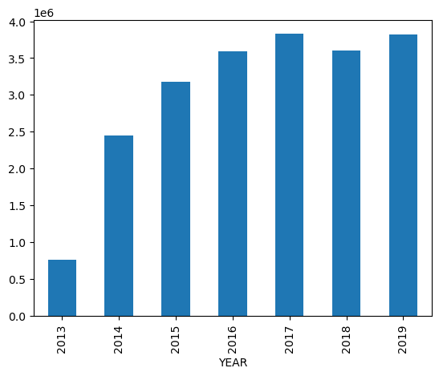

```python
bp_year_groups = year_groups.plot(kind="bar")
```

It is shown that there is an increasing trend for years and this growth was dramatic from 2013 to 2014 and one of the reasons is that our data start from the June 2013. Also, there was a litle decrease from 2017 to 2018.

```python
# Number of trips per month
```

```python
month_groups = df_MM_clean.groupby(["MONTH"]).size()
```

```python
print(month_groups)
```

```
MONTH
01     501857
02     546764
03     856606
04    1300373
05    2058411
06    2682608
07    3204041
08    3220608
09    2792511
10    2149156
11    1173737
12     755178
dtype: int64
```

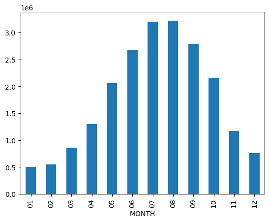

```python
bp_month_groups = month_groups.plot(kind="bar")
```

It shows that the majority of trips occur from June to October and it is less in cold months.

```python
# Number of trips per year and month
```

```python
month_year_groups = df_MM_clean.groupby(["YEAR", "MONTH"]).size()
```

```python
print(month_year_groups)
```

```
YEAR  MONTH
2013  06         4005
      07        74867
      08       170508
      09       201030
      10       174695
                ...
2019  08       590125
      09       493192
      10       371761
      11       177155
      12       155079
Length: 79, dtype: int64
```

```python
# Bar plot to show the year-month pattern of data
```

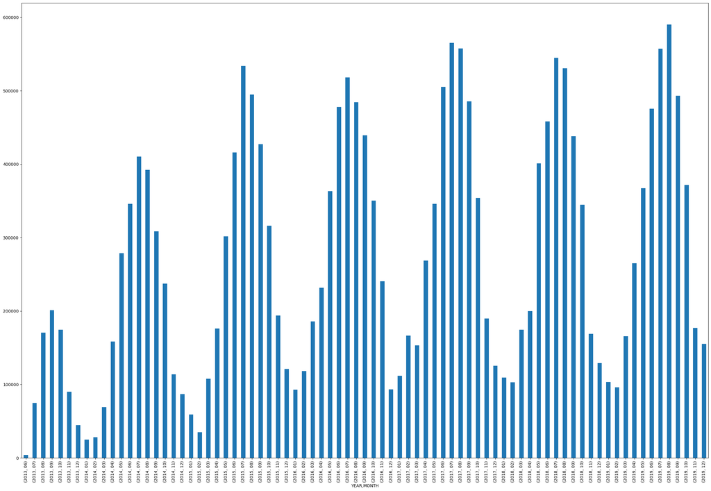

```python
bp_month_year_groups = month_year_groups.plot(kind="bar", figsize=(30, 20))
```

Number of records per year and month in micro-mobility dataset is shown above. It can be seen that majority of data belong to the middle of each year (from June to October) and generaly every year the trend was increasing.

...........................................................................................

- identify patterns e.g.,:
- Are there more vehicles as years go on ?
- Is there some change in usage patterns among different days of the week , months is there a trend – seasonal or weekly ?
- Are there any trends based on the gender and age of the user ?

```python
df_MM_clean.info()
```

```
<class 'pandas.core.frame.DataFrame'>
Int64Index: 21241850 entries, 0 to 21242739
Data columns (total 22 columns):
 #   Column             Dtype
---  ------             -----
 0   TRIP ID            int64
 1   START TIME         object
 2   STOP TIME          object
 3   BIKE ID            int64
 4   TRIP DURATION      int64
 5   FROM STATION ID    int64
 6   FROM STATION NAME  object
 7   TO STATION ID      int64
 8   TO STATION NAME    object
 9   USER TYPE          object
 10  GENDER             object
 11  BIRTH YEAR         float64
 12  FROM LATITUDE      float64
 13  FROM LONGITUDE     float64
 14  FROM LOCATION      object
 15  TO LATITUDE        float64
 16  TO LONGITUDE       float64
 17  TO LOCATION        object
 18  YEAR               object
 19  MONTH              object
 20  SEASON             object
 21  DAY OF WEEK        object
dtypes: float64(5), int64(5), object(12)
memory usage: 3.6+ GB
```

```python
# Comparing used bicycles in different years
```

```python
vehicle_groups = df_MM_clean.groupby(["YEAR", "BIKE ID"]).size()
```

```python
print(vehicle_groups)
```

```
YEAR  BIKE ID
2013  1          397
      2          342
      3          430
      4          352
      5          346
                ...
2019  6929       111
      6931        91
      6941        16
      6942        99
      6946        67
Length: 34712, dtype: int64
```

```python
# Analyzing seasonal trends
```

```python
season_groups = df_MM_clean.groupby(["SEASON"]).size()
```

```python
print(season_groups)
```

```
SEASON
Autumn    6115404
Spring    4215390
Summer    9107257
Winter    1803799
dtype: int64
```

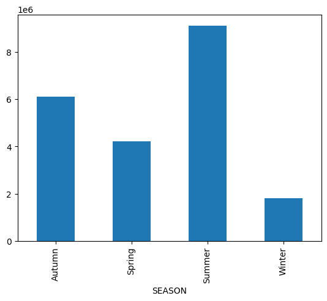

```python
bp_season_groups = season_groups.plot(kind="bar")
```

It shows that most of the trips happened on Summer and after that on Autumn

```python
vehicle_season_groups = df_MM_clean.groupby(["SEASON", "BIKE ID"]).size()
```

```python
print(vehicle_season_groups)
```

```
SEASON  BIKE ID
Autumn  1           995
        2          1026
        3          1016
        4           904
        5           803
                   ...
Winter  6913         11
        6929         41
        6931         21
        6942         35
        6946          8
Length: 25647, dtype: int64
```

```python
vehicle_month_groups = df_MM_clean.groupby(["YEAR", "MONTH", "BIKE ID"]).size()
```

```python
print(vehicle_month_groups)
```

```
YEAR  MONTH  BIKE ID
2013  06     1           7
             4           3
             5           4
             8           4
             19          2
                        ..
2019  12     6913       11
             6929       41
             6931       21
             6942       35
             6946        8
Length: 324337, dtype: int64
```

```python
# Analyzing weekly trends
```

```python
week_groups = df_MM_clean.groupby(["DAY OF WEEK"]).size()
```

```python
print(week_groups)
```

```
DAY OF WEEK
Friday       3125963
Monday       3114367
Saturday     2949008
Sunday       2700688
Thursday     3100101
Tuesday      3164302
Wednesday    3087421
dtype: int64
```

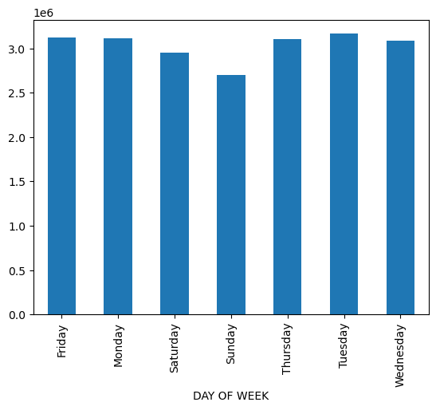

```python
bp_week_groups = week_groups.plot(kind="bar")
```

It shows that most of the trips happened on weekdays but the difference is not very significant

```python
vehicle_week_groups = df_MM_clean.groupby(["DAY OF WEEK", "BIKE ID"]).size()
```

```python
print(vehicle_week_groups)
```

```
DAY OF WEEK  BIKE ID
Friday       1          634
             2          516
             3          631
             4          524
             5          540
                       ...
Wednesday    6913         9
             6929        16
             6931        17
             6942        18
             6946        13
Length: 45556, dtype: int64
```

...........................................................................................

```python
# Now I am going to clean the data again based on GENDER and BIRTH YEAR
df_MM_clean_GB = df_MM_clean.dropna(axis=0)
```

```python
df_MM_clean_GB.count()
```

```
TRIP ID              16346709
START TIME           16346709
STOP TIME            16346709
BIKE ID              16346709
TRIP DURATION        16346709
FROM STATION ID      16346709
FROM STATION NAME    16346709
TO STATION ID        16346709
TO STATION NAME      16346709
USER TYPE            16346709
GENDER               16346709
BIRTH YEAR           16346709
FROM LATITUDE        16346709
FROM LONGITUDE       16346709
FROM LOCATION        16346709
TO LATITUDE          16346709
TO LONGITUDE         16346709
TO LOCATION          16346709
YEAR                 16346709
MONTH                16346709
SEASON               16346709
DAY OF WEEK          16346709
dtype: int64
```

Now there are 16,346,709 rows for all the columns.

```python
df_MM_clean_GB['GENDER'].value_counts()
```

```
Male      12234473
Female     4112236
Name: GENDER, dtype: int64
```

```python
gender_year_groups = df_MM_clean_GB.groupby(["YEAR", "GENDER"]).size()
```

```python
print(gender_year_groups)
```

```
YEAR  GENDER
2013  Female      84450
      Male       318459
2014  Female     407621
      Male      1255655
2015  Female     567305
      Male      1685970
2016  Female     689757
      Male      2047132
2017  Female     746633
      Male      2245291
2018  Female     758533
      Male      2281309
2019  Female     857937
      Male      2400657
dtype: int64
```

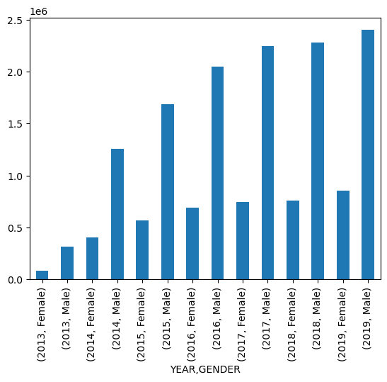

```python
bp_gender_year_groups = gender_year_groups.plot(kind="bar")
```

It is shown that in general through these years the number of trips increased but the share of males have been always way more than females

```python
# Evaluating the gender trends within months
```

```python
gender_month_groups = df_MM_clean_GB.groupby(["MONTH", "GENDER"]).size()
```

```python
print(gender_month_groups)
```

```
MONTH  GENDER
01     Female      89020
       Male       392150
02     Female      96448
       Male       407178
03     Female     157775
       Male       598513
04     Female     239797
       Male       798489
05     Female     381690
       Male      1128445
06     Female     534988
       Male      1415071
07     Female     621202
       Male      1576116
08     Female     633053
       Male      1663349
09     Female     555491
       Male      1531561
10     Female     432367
       Male      1336743
11     Female     229574
       Male       820540
12     Female     140831
       Male       566318
dtype: int64
```

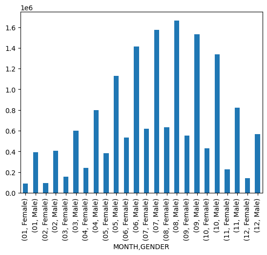

```python
bp_gender_month_groups = gender_month_groups.plot(kind="bar")
```

The same pattern is here for both males and females, warmer months are more delightful to use these modes of transport.

...........................................................................................

```python
# Calculating the minimum and maximum of "BIRTH YEAR" in order to find out the data
```

```python
df_MM_clean_GB['BIRTH YEAR'].min()
```

```
1759.0
```

```python
df_MM_clean_GB['BIRTH YEAR'].max()
```

```
2017.0
```

```python
# Check the "birth year" column to find out "bad data"
```

```python
df_MM_clean_GB['BIRTH YEAR'].value_counts()
```

```
1989.0    928536
1988.0    850181
1990.0    837904
1987.0    823726
1986.0    789516
           ...
1925.0         2
1895.0         1
2005.0         1
1759.0         1
1790.0         1
Name: BIRTH YEAR, Length: 103, dtype: int64
```

It is shown that there are some data which are obviously incorrect such as 1790. So, I am getting rid of these data.

```python
# Drop incorrect rows
df_MM_clean_B = df_MM_clean_GB[df_MM_clean_GB['BIRTH YEAR'] >= 1925]
```

```python
df_MM_clean_B.count()
```

```
TRIP ID              16340176
START TIME           16340176
STOP TIME            16340176
BIKE ID              16340176
TRIP DURATION        16340176
FROM STATION ID      16340176
FROM STATION NAME    16340176
TO STATION ID        16340176
TO STATION NAME      16340176
USER TYPE            16340176
GENDER               16340176
BIRTH YEAR           16340176
FROM LATITUDE        16340176
FROM LONGITUDE       16340176
FROM LOCATION        16340176
TO LATITUDE          16340176
TO LONGITUDE         16340176
TO LOCATION          16340176
YEAR                 16340176
MONTH                16340176
SEASON               16340176
DAY OF WEEK          16340176
dtype: int64
```

```python
df_MM_clean_B['BIRTH YEAR'].min()
```

```
1925.0
```

Now we can say that the minimum of BIRTH YEAR is 1925 and the maximum of it is 2017.

```python
df_MM_clean_B = df_MM_clean_B.dropna(subset=['BIRTH YEAR'])
```

```python
# Convert BIRTH YEAR and YEAR to integer
df_MM_clean_B['BIRTH YEAR'] = df_MM_clean_B['BIRTH YEAR'].astype('int')
df_MM_clean_B['YEAR'] = df_MM_clean_B['YEAR'].astype('int')
```

```python
# Create age groups based on the age distribution of users
df_MM_clean_B['age'] = df_MM_clean_B['YEAR'] - df_MM_clean_B['BIRTH YEAR']
```

```python
# Define age groups
age_bins = [0, 18, 30, 40, 50, 60, float('inf')]  # Define age bins/ranges
age_labels = ['0-18', '19-30', '31-40', '41-50', '51-60', '61+']  # Define corresponding labels
```

```python
# Create 'age group' column using pd.cut
df_MM_clean_B['age group'] = pd.cut(df_MM_clean_B['age'], bins=age_bins, labels=age_labels, right=False)
```

```python
age_groups = df_MM_clean_B.groupby("age group").size()
```

```python
print(age_groups)
```

```
age group
0-18       15967
19-30    6058860
31-40    5759775
41-50    2366332
51-60    1584683
61+       554559
dtype: int64
```

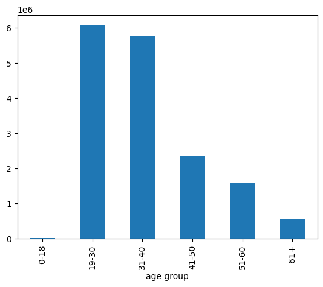

```python
bp_age_groups = age_groups.plot(kind="bar")
```

It can be seen that the majority of users belong to the age group between 19-40 years old.

```python
# Evaluating the age trend within years
```

```python
age_year_groups = df_MM_clean_B.groupby(["YEAR", "age group"]).size()
```

```python
print(age_year_groups)
```

[output not shown]

```python
bp_age_year_groups = age_year_groups.plot(kind="bar", figsize=(30, 20))
```

[output not shown]

# 2 - OD Matrices

In this section, I am going to do these tasks:

- Associate each trip in the dataset to an origin and destination ward by combining the trip information with the information about the wards. Check which wards the FROM_LOCATION and TO_LOCATION fields belong to.
- Compute then the O-D matrix, i.e., the number of bookings starting in ward i and ending in ward j.
- Prepare OD matrices for different years and different age groups(3 OD matrices for each age-group of 3 consecutive years). Are there any periodicity or trends noticed? Is there a difference between the OD matrices for different age groups?
- Based on observation, visualise selected OD matrices that show some trends/periodicity on a map.
- Create a flowmap for the OD matrices.

```python
# First I installed geopandas in order to do spatial analysis and determine each trip point (from/to) is within which ward of Chicago based on latitude and longitude
```

```python
pip install geopandas
```

[output not shown]

```python
pip install rtree
```

```python
pip install pygeos
```

```
  Using cached pygeos-0.14-cp37-cp37m-manylinux_2_17_x86_64.manylinux2014_x86_64.whl (2.1 MB)
```

```python
# In this part, because the size of the file is too much large and I encountered memory issues for spatial joining, I decided to select only 3 years to work on.
```

```python
df_MM_clean_2016 = df_MM_clean[df_MM_clean['YEAR'] == '2016']
```

```python
import geopandas as gpd
from shapely import wkt
```

```python
# Convert 'the_geom' in wards_chicago from WKT(Well Known text) to shapely objects
# 'the_geom' column contains MULTIPOLYGON data in text format
df_boundaries['the_geom'] = df_boundaries['the_geom'].apply(wkt.loads)
wards_gdf = gpd.GeoDataFrame(df_boundaries, geometry='the_geom')
```

[output not shown]

```python
# Convert 'FROM LOCATION' and 'TO LOCATION' in df_chicago from WKT to shapely Point objects
# These columns contain POINT data in text format
df_MM_clean_2016['from_point'] = df_MM_clean_2016['FROM LOCATION'].apply(wkt.loads)
df_from_gdf_2016 = gpd.GeoDataFrame(df_MM_clean_2016, geometry='from_point')
```

```python
df_MM_clean_2016['to_point'] = df_MM_clean_2016['TO LOCATION'].apply(wkt.loads)
df_to_gdf_2016 = gpd.GeoDataFrame(df_MM_clean_2016, geometry='to_point')
```

```python
# Ensure the CRS for both GeoDataFrames are the same
# This can be done by setting the CRS(Co-ordinate Reference System) of df_from_gdf and df_to_gdf to match that of wards_gdf

df_from_gdf_2016 = df_from_gdf_2016.set_crs('EPSG:4326', inplace=True,allow_override = True)
df_to_gdf_2016 = df_to_gdf_2016.set_crs('EPSG:4326', inplace=True,allow_override = True)
wards_gdf = wards_gdf.set_crs('EPSG:4326', inplace=True,allow_override = True)
```

```python
# Perform spatial joins
# Join df_from_gdf and df_to_gdf with wards_gdf to find the corresponding wards
from_joined_2016 = gpd.sjoin(df_from_gdf_2016, wards_gdf, how="left", op='within')
```

```python
to_joined_2016 = gpd.sjoin(df_to_gdf_2016, wards_gdf, how="left", op='within')
```

```python
# Add the ward information back to the original df_chicago DataFrame
df_MM_clean_2016['FROM WARD'] = from_joined_2016['Ward']  # Replace 'Ward' with the actual column name in wards_gdf
df_MM_clean_2016['TO WARD'] = to_joined_2016['Ward']      # Replace 'Ward' with the actual column name in wards_gdf
```

```python
df_MM_clean_2016.to_csv("df_MM_clean_2016", index=False)
```

```python
# Display the first few rows of the updated df_chicago to check the results
df_MM_clean_2016.head()
```

|  | TRIP ID | START TIME | STOP TIME | BIKE ID | TRIP DURATION | FROM STATION ID | FROM STATION NAME | TO STATION ID | TO STATION NAME | USER TYPE | ... | FROM LONGITUDE | FROM LOCATION | TO LATITUDE | TO LONGITUDE | TO LOCATION | YEAR | from_point | to_point | FROM WARD | TO WARD |
| --- | --- | --- | --- | --- | --- | --- | --- | --- | --- | --- | --- | --- | --- | --- | --- | --- | --- | --- | --- | --- | --- |
| 6397658 | 10000000 | 06/09/2016 06:24:00 PM | 06/09/2016 06:33:00 PM | 5 | 516 | 26 | McClurg Ct & Illinois St | 90 | Millennium Park | Subscriber | ... | -87.617300 | POINT (-87.6173 41.89102) | 41.881032 | -87.624084 | POINT (-87.624084 41.881032) | 2016 | POINT (-87.61730 41.89102) | POINT (-87.62408 41.88103) | 42.0 | 42.0 |
| 6397659 | 10000001 | 06/09/2016 06:24:00 PM | 06/09/2016 06:27:00 PM | 4201 | 163 | 238 | Ravenswood Ave & Montrose Ave (*) | 234 | Clark St & Montrose Ave | Subscriber | ... | -87.674365 | POINT (-87.674365 41.961615) | 41.961588 | -87.666036 | POINT (-87.666036 41.961588) | 2016 | POINT (-87.67436 41.96162) | POINT (-87.66604 41.96159) | 47.0 | 47.0 |
| 6397660 | 10000002 | 06/09/2016 06:25:00 PM | 06/09/2016 06:41:00 PM | 1976 | 987 | 91 | Clinton St & Washington Blvd | 289 | Wells St & Concord Ln | Subscriber | ... | -87.641170 | POINT (-87.64117 41.88338) | 41.912133 | -87.634656 | POINT (-87.634656 41.912133) | 2016 | POINT (-87.64117 41.88338) | POINT (-87.63466 41.91213) | 42.0 | 2.0 |
| 6397661 | 10000003 | 06/09/2016 06:25:00 PM | 06/09/2016 06:33:00 PM | 5354 | 518 | 310 | Damen Ave & Charleston St | 327 | Sheffield Ave & Webster Ave | Subscriber | ... | -87.677855 | POINT (-87.677855 41.920082) | 41.921540 | -87.653818 | POINT (-87.653818 41.92154) | 2016 | POINT (-87.67785 41.92008) | POINT (-87.65382 41.92154) | 32.0 | 43.0 |
| 6397662 | 10000005 | 06/09/2016 06:25:00 PM | 06/09/2016 06:38:00 PM | 4365 | 813 | 20 | Sheffield Ave & Kingsbury St | 153 | Southport Ave & Wellington Ave | Subscriber | ... | -87.653106 | POINT (-87.653106 41.910522) | 41.935733 | -87.663576 | POINT (-87.663576 41.935733) | 2016 | POINT (-87.65311 41.91052) | POINT (-87.66358 41.93573) | 27.0 | 32.0 |

5 rows × 23 columns

```python
df_MM_clean_2017 = df_MM_clean[df_MM_clean['YEAR'] == '2017']
```

```python
# Convert 'FROM LOCATION' and 'TO LOCATION' in df_chicago from WKT to shapely Point objects
# These columns contain POINT data in text format
df_MM_clean_2017['from_point'] = df_MM_clean_2017['FROM LOCATION'].apply(wkt.loads)
df_from_gdf_2017 = gpd.GeoDataFrame(df_MM_clean_2017, geometry='from_point')
df_MM_clean_2017['to_point'] = df_MM_clean_2017['TO LOCATION'].apply(wkt.loads)
df_to_gdf_2017 = gpd.GeoDataFrame(df_MM_clean_2017, geometry='to_point')
```

```python
# Ensure the CRS for both GeoDataFrames are the same
# This can be done by setting the CRS(Co-ordinate Reference System) of df_from_gdf and df_to_gdf to match that of wards_gdf
df_from_gdf_2017 = df_from_gdf_2017.set_crs('EPSG:4326', inplace=True,allow_override = True)
df_to_gdf_2017 = df_to_gdf_2017.set_crs('EPSG:4326', inplace=True,allow_override = True)
wards_gdf = wards_gdf.set_crs('EPSG:4326', inplace=True,allow_override = True)
```

```python
# Perform spatial joins
# Join df_from_gdf and df_to_gdf with wards_gdf to find the corresponding wards
from_joined_2017 = gpd.sjoin(df_from_gdf_2017, wards_gdf, how="left", op='within')
to_joined_2017 = gpd.sjoin(df_to_gdf_2017, wards_gdf, how="left", op='within')
```

```python
# Add the ward information back to the original df_chicago DataFrame
df_MM_clean_2017['FROM WARD'] = from_joined_2017['Ward']  # Replace 'Ward' with the actual column name in wards_gdf
df_MM_clean_2017['TO WARD'] = to_joined_2017['Ward']      # Replace 'Ward' with the actual column name in wards_gdf
```

```python
df_MM_clean_2017.to_csv("df_MM_clean_2017", index=False)
```

```python
# Display the first few rows of the updated df_chicago to check the results
df_MM_clean_2017.head()
```

|  | TRIP ID | START TIME | STOP TIME | BIKE ID | TRIP DURATION | FROM STATION ID | FROM STATION NAME | TO STATION ID | TO STATION NAME | USER TYPE | ... | FROM LONGITUDE | FROM LOCATION | TO LATITUDE | TO LONGITUDE | TO LOCATION | YEAR | from_point | to_point | FROM WARD | TO WARD |
| --- | --- | --- | --- | --- | --- | --- | --- | --- | --- | --- | --- | --- | --- | --- | --- | --- | --- | --- | --- | --- | --- |
| 9992991 | 12979230 | 01/01/2017 12:00:00 AM | 01/01/2017 12:06:00 AM | 2511 | 356 | 414 | Canal St & Taylor St | 191 | Canal St & Monroe St (*) | Customer | ... | -87.639474 | POINT (-87.639474 41.870257) | 41.880884 | -87.639525 | POINT (-87.639525 41.880884) | 2017 | POINT (-87.63947 41.87026) | POINT (-87.63953 41.88088) | 28.0 | 42.0 |
| 9992992 | 12979231 | 01/01/2017 12:02:00 AM | 01/01/2017 12:08:00 AM | 3660 | 327 | 28 | Larrabee St & Menomonee St | 20 | Sheffield Ave & Kingsbury St | Subscriber | ... | -87.643320 | POINT (-87.64332 41.91468) | 41.910522 | -87.653106 | POINT (-87.653106 41.910522) | 2017 | POINT (-87.64332 41.91468) | POINT (-87.65311 41.91052) | 43.0 | 27.0 |
| 9992993 | 12979232 | 01/01/2017 12:06:00 AM | 01/01/2017 12:18:00 AM | 4992 | 745 | 620 | Orleans St & Chestnut St (NEXT Apts) | 333 | Ashland Ave & Blackhawk St | Subscriber | ... | -87.637536 | POINT (-87.637536 41.898203) | 41.907066 | -87.667252 | POINT (-87.667252 41.907066) | 2017 | POINT (-87.63754 41.89820) | POINT (-87.66725 41.90707) | 2.0 | 1.0 |
| 9992994 | 12979233 | 01/01/2017 12:07:00 AM | 01/01/2017 12:12:00 AM | 5637 | 323 | 287 | Franklin St & Monroe St | 68 | Clinton St & Tilden St | Subscriber | ... | -87.635185 | POINT (-87.635185 41.880317) | 41.875885 | -87.640795 | POINT (-87.640795 41.875885) | 2017 | POINT (-87.63519 41.88032) | POINT (-87.64079 41.87588) | 42.0 | 28.0 |
| 9992995 | 12979234 | 01/01/2017 12:07:00 AM | 01/01/2017 12:20:00 AM | 2209 | 776 | 300 | Broadway & Barry Ave | 118 | Sedgwick St & North Ave | Subscriber | ... | -87.644095 | POINT (-87.644095 41.937725) | 41.911386 | -87.638677 | POINT (-87.638677 41.911386) | 2017 | POINT (-87.64409 41.93773) | POINT (-87.63868 41.91139) | 44.0 | 2.0 |

5 rows × 23 columns

```python
df_MM_clean_2018 = df_MM_clean[df_MM_clean['YEAR'] == '2018']
```

```python
# Convert 'FROM LOCATION' and 'TO LOCATION' in df_chicago from WKT to shapely Point objects
# These columns contain POINT data in text format
df_MM_clean_2018['from_point'] = df_MM_clean_2018['FROM LOCATION'].apply(wkt.loads)
df_from_gdf_2018 = gpd.GeoDataFrame(df_MM_clean_2018, geometry='from_point')
df_MM_clean_2018['to_point'] = df_MM_clean_2018['TO LOCATION'].apply(wkt.loads)
df_to_gdf_2018 = gpd.GeoDataFrame(df_MM_clean_2018, geometry='to_point')
```

```python
# Ensure the CRS for both GeoDataFrames are the same
# This can be done by setting the CRS(Co-ordinate Reference System) of df_from_gdf and df_to_gdf to match that of wards_gdf
df_from_gdf_2018 = df_from_gdf_2018.set_crs('EPSG:4326', inplace=True,allow_override = True)
df_to_gdf_2018 = df_to_gdf_2018.set_crs('EPSG:4326', inplace=True,allow_override = True)
wards_gdf = wards_gdf.set_crs('EPSG:4326', inplace=True,allow_override = True)
```

```python
# Perform spatial joins
# Join df_from_gdf and df_to_gdf with wards_gdf to find the corresponding wards
from_joined_2018 = gpd.sjoin(df_from_gdf_2018, wards_gdf, how="left", op='within')
to_joined_2018 = gpd.sjoin(df_to_gdf_2018, wards_gdf, how="left", op='within')
```

```python
# Add the ward information back to the original df_chicago DataFrame
df_MM_clean_2018['FROM WARD'] = from_joined_2018['Ward']  # Replace 'Ward' with the actual column name in wards_gdf
df_MM_clean_2018['TO WARD'] = to_joined_2018['Ward']      # Replace 'Ward' with the actual column name in wards_gdf
```

```python
df_MM_clean_2018.to_csv("df_MM_clean_2018", index=False)
```

```python
# Display the first few rows of the updated df_chicago to check the results
df_MM_clean_2018.head()
```

|  | TRIP ID | START TIME | STOP TIME | BIKE ID | TRIP DURATION | FROM STATION ID | FROM STATION NAME | TO STATION ID | TO STATION NAME | USER TYPE | ... | FROM LONGITUDE | FROM LOCATION | TO LATITUDE | TO LONGITUDE | TO LOCATION | YEAR | from_point | to_point | FROM WARD | TO WARD |
| --- | --- | --- | --- | --- | --- | --- | --- | --- | --- | --- | --- | --- | --- | --- | --- | --- | --- | --- | --- | --- | --- |
| 11544487 | 18511623 | 05/21/2018 05:07:29 PM | 05/21/2018 05:11:48 PM | 153 | 259 | 51 | Clark St & Randolph St | 91 | Clinton St & Washington Blvd | Subscriber | ... | -87.631890 | POINT (-87.63188991 41.884576228) | 41.883380 | -87.641170 | POINT (-87.64117 41.88338) | 2018 | POINT (-87.63189 41.88458) | POINT (-87.64117 41.88338) | 42.0 | 42.0 |
| 11546857 | 18002370 | 04/01/2018 02:24:43 PM | 04/01/2018 02:38:54 PM | 3101 | 851 | 106 | State St & Pearson St | 174 | Canal St & Madison St | Subscriber | ... | -87.628722 | POINT (-87.628722 41.897448) | 41.882091 | -87.639833 | POINT (-87.639833 41.882091) | 2018 | POINT (-87.62872 41.89745) | POINT (-87.63983 41.88209) | 42.0 | 42.0 |
| 11546858 | 18002371 | 04/01/2018 02:25:30 PM | 04/01/2018 02:32:41 PM | 5226 | 431 | 426 | Ellis Ave & 60th St | 322 | Kimbark Ave & 53rd St | Subscriber | ... | -87.601073 | POINT (-87.6010727606 41.78509714636) | 41.799568 | -87.594747 | POINT (-87.594747 41.799568) | 2018 | POINT (-87.60107 41.78510) | POINT (-87.59475 41.79957) | 5.0 | 4.0 |
| 11546859 | 18002372 | 04/01/2018 02:25:51 PM | 04/01/2018 02:42:22 PM | 4861 | 991 | 110 | Dearborn St & Erie St | 31 | Franklin St & Chicago Ave | Subscriber | ... | -87.629318 | POINT (-87.629318 41.893992) | 41.896776 | -87.635633 | POINT (-87.635633 41.896776) | 2018 | POINT (-87.62932 41.89399) | POINT (-87.63563 41.89678) | 42.0 | 27.0 |
| 11546860 | 18002373 | 04/01/2018 02:25:58 PM | 04/01/2018 02:42:23 PM | 4706 | 985 | 214 | Damen Ave & Grand Ave | 47 | State St & Kinzie St | Subscriber | ... | -87.676860 | POINT (-87.67686 41.89122) | 41.889187 | -87.627754 | POINT (-87.627754 41.889187) | 2018 | POINT (-87.67686 41.89122) | POINT (-87.62775 41.88919) | 36.0 | 42.0 |

5 rows × 23 columns

...........................................................................................

- Compute then the O-D matrix, i.e., the number of bookings starting in ward i and ending in ward j.

```python
# OD Matrix 2016 calculation using pivot table
matrix_2016 = (
    df_MM_clean_2016.assign(count=1)
    .pivot_table(index='FROM WARD', columns='TO WARD',
                 values="count", aggfunc="count")
    .fillna(0)
    .astype(int)
).sort_values('FROM WARD')

matrix_2016
```

| TO WARD FROM WARD | 1.0 | 2.0 | 3.0 | 4.0 | 5.0 | 6.0 | 7.0 | 8.0 | 11.0 | 12.0 | ... | 40.0 | 42.0 | 43.0 | 44.0 | 45.0 | 46.0 | 47.0 | 48.0 | 49.0 | 50.0 |
| --- | --- | --- | --- | --- | --- | --- | --- | --- | --- | --- | --- | --- | --- | --- | --- | --- | --- | --- | --- | --- | --- |
| 1.0 | 42043 | 4799 | 36 | 470 | 4 | 0 | 0 | 0 | 11 | 4 | ... | 45 | 16561 | 5696 | 1931 | 103 | 332 | 1834 | 41 | 4 | 1 |
| 2.0 | 5666 | 29050 | 1399 | 3143 | 11 | 0 | 0 | 0 | 62 | 0 | ... | 21 | 58381 | 34166 | 7603 | 2 | 3214 | 832 | 395 | 20 | 0 |
| 3.0 | 46 | 1328 | 5832 | 10919 | 1165 | 2 | 0 | 1 | 2519 | 29 | ... | 0 | 9427 | 199 | 3 | 1 | 8 | 3 | 2 | 0 | 0 |
| 4.0 | 482 | 3534 | 12072 | 26365 | 9868 | 0 | 4 | 2 | 2880 | 24 | ... | 9 | 27605 | 1154 | 125 | 2 | 43 | 24 | 8 | 1 | 2 |
| 5.0 | 3 | 7 | 1107 | 9704 | 32426 | 48 | 126 | 212 | 32 | 0 | ... | 0 | 132 | 3 | 2 | 0 | 2 | 0 | 2 | 0 | 0 |
| 6.0 | 0 | 0 | 3 | 1 | 46 | 133 | 0 | 61 | 0 | 0 | ... | 0 | 0 | 0 | 0 | 0 | 0 | 0 | 0 | 0 | 0 |
| 7.0 | 0 | 0 | 0 | 3 | 114 | 3 | 356 | 29 | 0 | 0 | ... | 0 | 0 | 0 | 0 | 0 | 0 | 0 | 0 | 0 | 0 |
| 8.0 | 0 | 0 | 1 | 1 | 207 | 68 | 36 | 147 | 0 | 0 | ... | 0 | 0 | 0 | 0 | 0 | 0 | 0 | 0 | 0 | 0 |
| 11.0 | 34 | 45 | 2365 | 2742 | 19 | 0 | 0 | 0 | 11505 | 431 | ... | 0 | 1589 | 23 | 5 | 0 | 2 | 1 | 1 | 0 | 0 |
| 12.0 | 2 | 1 | 51 | 38 | 0 | 0 | 0 | 0 | 414 | 199 | ... | 0 | 2 | 1 | 0 | 0 | 0 | 0 | 0 | 0 | 0 |
| 15.0 | 0 | 0 | 1 | 17 | 0 | 0 | 0 | 0 | 67 | 45 | ... | 0 | 1 | 0 | 0 | 0 | 0 | 0 | 0 | 0 | 0 |
| 16.0 | 1 | 0 | 3 | 1 | 3 | 5 | 0 | 0 | 4 | 2 | ... | 0 | 0 | 0 | 0 | 0 | 0 | 0 | 0 | 0 | 0 |
| 17.0 | 1 | 0 | 0 | 0 | 0 | 0 | 0 | 0 | 1 | 0 | ... | 0 | 0 | 0 | 0 | 0 | 0 | 0 | 0 | 0 | 0 |
| 20.0 | 0 | 0 | 617 | 342 | 1086 | 37 | 2 | 17 | 196 | 7 | ... | 0 | 1 | 0 | 0 | 0 | 0 | 0 | 0 | 0 | 0 |
| 22.0 | 4 | 0 | 0 | 0 | 0 | 0 | 0 | 0 | 3 | 4 | ... | 0 | 1 | 0 | 0 | 0 | 0 | 0 | 0 | 0 | 0 |
| 24.0 | 45 | 0 | 1 | 2 | 0 | 0 | 0 | 0 | 0 | 6 | ... | 0 | 5 | 0 | 0 | 9 | 0 | 2 | 0 | 0 | 0 |
| 25.0 | 560 | 104 | 906 | 1067 | 16 | 0 | 0 | 0 | 1637 | 252 | ... | 2 | 3185 | 119 | 18 | 0 | 4 | 0 | 14 | 0 | 0 |
| 26.0 | 6498 | 357 | 1 | 7 | 0 | 0 | 0 | 0 | 3 | 2 | ... | 2 | 1302 | 304 | 51 | 6 | 15 | 82 | 4 | 0 | 0 |
| 27.0 | 15413 | 20016 | 457 | 2271 | 2 | 0 | 0 | 0 | 408 | 145 | ... | 14 | 62672 | 16815 | 4424 | 3 | 1151 | 802 | 31 | 7 | 4 |
| 28.0 | 777 | 556 | 907 | 2774 | 1 | 0 | 0 | 0 | 1470 | 37 | ... | 0 | 7875 | 341 | 56 | 1 | 8 | 7 | 3 | 3 | 0 |
| 29.0 | 1 | 0 | 1 | 0 | 0 | 0 | 0 | 0 | 0 | 0 | ... | 0 | 1 | 0 | 0 | 0 | 0 | 0 | 0 | 0 | 0 |
| 30.0 | 232 | 2 | 0 | 1 | 0 | 0 | 0 | 0 | 0 | 0 | ... | 12 | 3 | 2 | 54 | 113 | 14 | 107 | 0 | 0 | 0 |
| 32.0 | 16348 | 3622 | 6 | 101 | 28 | 0 | 0 | 0 | 5 | 3 | ... | 343 | 5527 | 25166 | 15397 | 122 | 2545 | 9112 | 297 | 14 | 5 |
| 33.0 | 460 | 56 | 0 | 0 | 0 | 0 | 0 | 0 | 0 | 0 | ... | 577 | 10 | 165 | 275 | 230 | 422 | 1803 | 124 | 7 | 21 |
| 34.0 | 8598 | 21895 | 12189 | 21173 | 32 | 0 | 0 | 0 | 2331 | 86 | ... | 8 | 123180 | 9069 | 1435 | 0 | 233 | 171 | 18 | 13 | 6 |
| 35.0 | 5596 | 102 | 0 | 8 | 0 | 0 | 0 | 0 | 1 | 1 | ... | 135 | 332 | 708 | 709 | 377 | 138 | 1025 | 56 | 4 | 2 |
| 36.0 | 6557 | 822 | 9 | 43 | 0 | 0 | 0 | 0 | 11 | 5 | ... | 6 | 3573 | 369 | 90 | 3 | 26 | 109 | 2 | 0 | 0 |
| 37.0 | 0 | 0 | 0 | 0 | 0 | 0 | 0 | 0 | 0 | 0 | ... | 0 | 0 | 0 | 0 | 0 | 0 | 0 | 0 | 0 | 0 |
| 39.0 | 92 | 5 | 0 | 0 | 0 | 0 | 0 | 0 | 0 | 0 | ... | 324 | 0 | 7 | 18 | 179 | 116 | 463 | 129 | 14 | 19 |
| 40.0 | 86 | 16 | 0 | 7 | 0 | 0 | 0 | 0 | 0 | 1 | ... | 3329 | 33 | 284 | 493 | 64 | 840 | 6624 | 2771 | 1807 | 189 |
| 42.0 | 17588 | 63031 | 9717 | 26721 | 114 | 1 | 0 | 0 | 1426 | 4 | ... | 27 | 234102 | 42308 | 7507 | 6 | 2077 | 815 | 425 | 44 | 12 |
| 43.0 | 5807 | 30248 | 134 | 1050 | 9 | 0 | 0 | 0 | 11 | 0 | ... | 240 | 34691 | 99908 | 27845 | 8 | 12764 | 5195 | 3223 | 56 | 1 |
| 44.0 | 1821 | 6400 | 8 | 95 | 3 | 0 | 0 | 0 | 2 | 0 | ... | 502 | 5601 | 24680 | 37549 | 56 | 20203 | 10325 | 2724 | 145 | 4 |
| 45.0 | 114 | 3 | 0 | 0 | 0 | 0 | 0 | 0 | 0 | 0 | ... | 36 | 0 | 19 | 72 | 702 | 73 | 317 | 7 | 0 | 0 |
| 46.0 | 244 | 2562 | 9 | 26 | 0 | 0 | 0 | 0 | 0 | 0 | ... | 880 | 1524 | 12065 | 20376 | 63 | 44674 | 11799 | 6453 | 397 | 12 |
| 47.0 | 1663 | 892 | 0 | 34 | 0 | 0 | 0 | 0 | 0 | 0 | ... | 7206 | 382 | 4469 | 9372 | 253 | 11695 | 40315 | 5765 | 467 | 94 |
| 48.0 | 39 | 230 | 2 | 7 | 1 | 0 | 0 | 0 | 0 | 0 | ... | 2935 | 179 | 2826 | 2556 | 4 | 5665 | 5096 | 12888 | 2308 | 137 |
| 49.0 | 2 | 12 | 1 | 2 | 0 | 0 | 0 | 0 | 0 | 0 | ... | 1871 | 26 | 58 | 138 | 0 | 366 | 474 | 2096 | 8675 | 187 |
| 50.0 | 2 | 0 | 0 | 0 | 0 | 0 | 0 | 0 | 0 | 0 | ... | 181 | 13 | 1 | 4 | 0 | 13 | 94 | 93 | 170 | 21 |

39 rows × 39 columns

```python
# OD Matrix 2017 calculation using pivot table
matrix_2017 = (
    df_MM_clean_2017.assign(count=1)
    .pivot_table(index='FROM WARD', columns='TO WARD',
                 values="count", aggfunc="count")
    .fillna(0)
    .astype(int)
).sort_values('FROM WARD')

matrix_2017
```

| TO WARD FROM WARD | 1.0 | 2.0 | 3.0 | 4.0 | 5.0 | 6.0 | 7.0 | 8.0 | 11.0 | 12.0 | ... | 40.0 | 42.0 | 43.0 | 44.0 | 45.0 | 46.0 | 47.0 | 48.0 | 49.0 | 50.0 |
| --- | --- | --- | --- | --- | --- | --- | --- | --- | --- | --- | --- | --- | --- | --- | --- | --- | --- | --- | --- | --- | --- |
| 1.0 | 43441 | 5944 | 48 | 495 | 10 | 0 | 0 | 0 | 23 | 8 | ... | 81 | 19523 | 7921 | 2268 | 206 | 405 | 1989 | 89 | 110 | 1 |
| 2.0 | 6570 | 55925 | 1693 | 8216 | 151 | 0 | 0 | 0 | 128 | 3 | ... | 42 | 98255 | 54460 | 11373 | 15 | 4576 | 988 | 762 | 95 | 2 |
| 3.0 | 57 | 1535 | 8353 | 19513 | 1729 | 4 | 0 | 3 | 3523 | 68 | ... | 0 | 11604 | 302 | 50 | 0 | 15 | 5 | 6 | 0 | 0 |
| 4.0 | 547 | 8826 | 21660 | 80686 | 14984 | 6 | 9 | 1 | 5316 | 20 | ... | 8 | 77324 | 3330 | 438 | 2 | 210 | 70 | 78 | 11 | 1 |
| 5.0 | 12 | 123 | 1632 | 15477 | 41837 | 27 | 167 | 216 | 82 | 4 | ... | 0 | 1075 | 61 | 17 | 0 | 7 | 0 | 4 | 0 | 0 |
| 6.0 | 0 | 0 | 4 | 3 | 28 | 881 | 10 | 220 | 1 | 0 | ... | 0 | 3 | 0 | 0 | 0 | 0 | 0 | 0 | 0 | 0 |
| 7.0 | 0 | 0 | 1 | 8 | 158 | 2 | 970 | 74 | 0 | 0 | ... | 0 | 1 | 1 | 0 | 0 | 0 | 0 | 0 | 0 | 0 |
| 8.0 | 0 | 0 | 2 | 5 | 221 | 220 | 70 | 383 | 0 | 0 | ... | 0 | 1 | 0 | 0 | 0 | 0 | 0 | 0 | 0 | 0 |
| 11.0 | 39 | 115 | 2918 | 4898 | 66 | 2 | 0 | 0 | 12175 | 485 | ... | 0 | 1975 | 40 | 7 | 0 | 3 | 2 | 2 | 0 | 0 |
| 12.0 | 1 | 1 | 140 | 28 | 2 | 0 | 0 | 0 | 458 | 480 | ... | 0 | 9 | 0 | 0 | 0 | 0 | 0 | 0 | 0 | 0 |
| 15.0 | 2 | 0 | 14 | 17 | 2 | 0 | 0 | 0 | 202 | 74 | ... | 0 | 0 | 0 | 0 | 0 | 0 | 0 | 0 | 0 | 0 |
| 16.0 | 7 | 0 | 21 | 5 | 10 | 21 | 1 | 0 | 23 | 19 | ... | 0 | 0 | 0 | 0 | 0 | 0 | 0 | 0 | 0 | 0 |
| 17.0 | 0 | 0 | 0 | 0 | 0 | 0 | 0 | 0 | 0 | 0 | ... | 0 | 0 | 0 | 0 | 0 | 0 | 0 | 0 | 0 | 0 |
| 20.0 | 0 | 5 | 782 | 506 | 1751 | 47 | 2 | 27 | 264 | 33 | ... | 0 | 14 | 5 | 0 | 0 | 0 | 0 | 0 | 0 | 0 |
| 22.0 | 0 | 0 | 0 | 6 | 0 | 0 | 0 | 0 | 1 | 6 | ... | 0 | 2 | 0 | 0 | 0 | 0 | 0 | 0 | 0 | 0 |
| 24.0 | 7 | 1 | 2 | 6 | 0 | 0 | 0 | 0 | 9 | 16 | ... | 0 | 14 | 6 | 1 | 0 | 0 | 0 | 0 | 0 | 0 |
| 25.0 | 568 | 289 | 1286 | 1626 | 35 | 0 | 0 | 0 | 1843 | 388 | ... | 1 | 3363 | 104 | 39 | 0 | 8 | 5 | 2 | 0 | 0 |
| 26.0 | 7367 | 359 | 3 | 24 | 0 | 0 | 0 | 0 | 3 | 5 | ... | 21 | 1167 | 543 | 92 | 17 | 15 | 238 | 5 | 0 | 2 |
| 27.0 | 18166 | 25614 | 444 | 2634 | 38 | 0 | 0 | 0 | 328 | 129 | ... | 18 | 69599 | 20149 | 4852 | 7 | 1034 | 845 | 81 | 16 | 3 |
| 28.0 | 690 | 765 | 1394 | 4419 | 8 | 0 | 0 | 0 | 1418 | 43 | ... | 1 | 9782 | 327 | 133 | 3 | 16 | 10 | 1 | 0 | 0 |
| 29.0 | 1 | 1 | 0 | 1 | 0 | 0 | 0 | 0 | 0 | 0 | ... | 0 | 1 | 1 | 0 | 2 | 0 | 0 | 0 | 1 | 0 |
| 30.0 | 230 | 5 | 0 | 1 | 0 | 0 | 0 | 0 | 0 | 0 | ... | 6 | 3 | 22 | 54 | 310 | 8 | 88 | 2 | 0 | 1 |
| 32.0 | 18910 | 4774 | 8 | 216 | 29 | 0 | 0 | 0 | 7 | 2 | ... | 392 | 6445 | 29296 | 16283 | 253 | 2752 | 9532 | 328 | 69 | 2 |
| 33.0 | 476 | 49 | 0 | 2 | 0 | 0 | 0 | 0 | 0 | 0 | ... | 655 | 20 | 212 | 355 | 440 | 539 | 2003 | 143 | 11 | 9 |
| 34.0 | 10811 | 29154 | 14630 | 32089 | 172 | 2 | 1 | 0 | 2960 | 117 | ... | 17 | 152442 | 11483 | 2147 | 11 | 354 | 203 | 70 | 19 | 1 |
| 35.0 | 6198 | 213 | 3 | 11 | 1 | 0 | 0 | 0 | 2 | 1 | ... | 203 | 450 | 1058 | 756 | 475 | 167 | 1071 | 49 | 7 | 3 |
| 36.0 | 8051 | 1071 | 15 | 89 | 0 | 0 | 0 | 2 | 13 | 2 | ... | 5 | 3527 | 587 | 209 | 6 | 45 | 199 | 11 | 1 | 0 |
| 37.0 | 2 | 0 | 0 | 0 | 0 | 0 | 0 | 0 | 0 | 0 | ... | 0 | 0 | 0 | 0 | 1 | 0 | 0 | 0 | 0 | 0 |
| 39.0 | 103 | 8 | 0 | 0 | 1 | 0 | 0 | 0 | 1 | 0 | ... | 362 | 3 | 16 | 28 | 187 | 67 | 554 | 175 | 24 | 20 |
| 40.0 | 126 | 51 | 1 | 16 | 0 | 0 | 0 | 0 | 0 | 0 | ... | 4156 | 60 | 323 | 685 | 88 | 1024 | 7172 | 3376 | 1885 | 299 |
| 42.0 | 20908 | 108470 | 11556 | 70192 | 1047 | 5 | 5 | 2 | 2010 | 21 | ... | 62 | 371506 | 77950 | 12228 | 21 | 3951 | 991 | 972 | 106 | 12 |
| 43.0 | 7680 | 49991 | 207 | 2540 | 65 | 0 | 0 | 0 | 33 | 2 | ... | 263 | 66598 | 141220 | 39999 | 19 | 18595 | 5670 | 4707 | 180 | 10 |
| 44.0 | 2254 | 9500 | 33 | 290 | 8 | 0 | 0 | 0 | 6 | 1 | ... | 739 | 10069 | 37410 | 48755 | 85 | 24818 | 10522 | 4701 | 397 | 18 |
| 45.0 | 213 | 17 | 1 | 1 | 0 | 0 | 0 | 0 | 0 | 0 | ... | 57 | 9 | 21 | 93 | 1166 | 86 | 406 | 31 | 4 | 0 |
| 46.0 | 324 | 3777 | 14 | 153 | 4 | 0 | 0 | 0 | 5 | 0 | ... | 994 | 3293 | 17842 | 24189 | 84 | 48647 | 11836 | 8914 | 666 | 14 |
| 47.0 | 1724 | 968 | 2 | 63 | 0 | 0 | 0 | 0 | 5 | 0 | ... | 7668 | 664 | 5251 | 10085 | 436 | 11738 | 41035 | 6310 | 626 | 105 |
| 48.0 | 94 | 663 | 6 | 63 | 6 | 0 | 0 | 0 | 4 | 0 | ... | 3566 | 793 | 4320 | 4605 | 37 | 7642 | 5508 | 15243 | 3297 | 404 |
| 49.0 | 91 | 69 | 0 | 8 | 1 | 0 | 0 | 0 | 1 | 0 | ... | 1987 | 106 | 165 | 198 | 2 | 602 | 595 | 3130 | 15682 | 231 |
| 50.0 | 3 | 3 | 0 | 1 | 1 | 0 | 0 | 0 | 0 | 0 | ... | 281 | 4 | 3 | 12 | 1 | 17 | 94 | 339 | 191 | 64 |

39 rows × 39 columns

```python
# OD Matrix 2018 calculation using pivot table
matrix_2018 = (
    df_MM_clean_2018.assign(count=1)
    .pivot_table(index='FROM WARD', columns='TO WARD',
                 values="count", aggfunc="count")
    .fillna(0)
    .astype(int)
).sort_values('FROM WARD')

matrix_2018
```

| TO WARD FROM WARD | 1.0 | 2.0 | 3.0 | 4.0 | 5.0 | 6.0 | 7.0 | 8.0 | 11.0 | 12.0 | ... | 40.0 | 42.0 | 43.0 | 44.0 | 45.0 | 46.0 | 47.0 | 48.0 | 49.0 | 50.0 |
| --- | --- | --- | --- | --- | --- | --- | --- | --- | --- | --- | --- | --- | --- | --- | --- | --- | --- | --- | --- | --- | --- |
| 1.0 | 42245 | 5377 | 148 | 699 | 37 | 0 | 0 | 2 | 123 | 137 | ... | 166 | 20375 | 7525 | 2511 | 187 | 751 | 1715 | 143 | 97 | 4 |
| 2.0 | 5974 | 50698 | 1541 | 7276 | 457 | 2 | 5 | 1 | 251 | 10 | ... | 131 | 83062 | 42812 | 10784 | 11 | 5531 | 1514 | 1182 | 177 | 4 |
| 3.0 | 167 | 1637 | 8206 | 15103 | 1756 | 11 | 0 | 7 | 3276 | 92 | ... | 4 | 12094 | 667 | 111 | 1 | 59 | 7 | 23 | 4 | 0 |
| 4.0 | 671 | 7861 | 17104 | 52161 | 14150 | 16 | 21 | 31 | 4240 | 47 | ... | 14 | 57861 | 4433 | 921 | 7 | 472 | 130 | 236 | 27 | 2 |
| 5.0 | 25 | 283 | 1731 | 14741 | 50077 | 94 | 233 | 179 | 173 | 4 | ... | 4 | 2565 | 196 | 41 | 0 | 29 | 3 | 25 | 9 | 0 |
| 6.0 | 0 | 0 | 7 | 6 | 96 | 906 | 18 | 221 | 0 | 0 | ... | 0 | 7 | 0 | 0 | 0 | 0 | 0 | 0 | 0 | 0 |
| 7.0 | 0 | 6 | 1 | 19 | 193 | 9 | 1176 | 53 | 0 | 0 | ... | 0 | 10 | 2 | 0 | 0 | 0 | 0 | 0 | 0 | 0 |
| 8.0 | 0 | 0 | 4 | 33 | 200 | 218 | 78 | 335 | 1 | 0 | ... | 0 | 6 | 1 | 1 | 0 | 0 | 0 | 0 | 0 | 0 |
| 11.0 | 115 | 259 | 2858 | 3930 | 155 | 1 | 0 | 1 | 11983 | 420 | ... | 0 | 2279 | 135 | 39 | 0 | 7 | 3 | 12 | 0 | 0 |
| 12.0 | 36 | 3 | 152 | 66 | 5 | 0 | 0 | 0 | 385 | 533 | ... | 0 | 35 | 2 | 0 | 0 | 0 | 0 | 0 | 0 | 0 |
| 15.0 | 1 | 0 | 11 | 32 | 17 | 2 | 0 | 0 | 167 | 226 | ... | 0 | 1 | 0 | 0 | 0 | 0 | 0 | 0 | 0 | 0 |
| 16.0 | 1 | 1 | 13 | 7 | 9 | 51 | 0 | 13 | 19 | 10 | ... | 0 | 8 | 0 | 0 | 0 | 0 | 0 | 0 | 0 | 0 |
| 17.0 | 0 | 0 | 0 | 1 | 0 | 10 | 0 | 0 | 0 | 0 | ... | 0 | 0 | 0 | 0 | 0 | 0 | 0 | 0 | 0 | 0 |
| 20.0 | 2 | 7 | 516 | 482 | 1835 | 102 | 10 | 62 | 155 | 26 | ... | 0 | 43 | 3 | 0 | 0 | 0 | 0 | 2 | 0 | 0 |
| 22.0 | 2 | 19 | 1 | 34 | 0 | 0 | 0 | 0 | 5 | 0 | ... | 0 | 12 | 1 | 0 | 0 | 0 | 0 | 0 | 0 | 0 |
| 24.0 | 17 | 8 | 3 | 24 | 1 | 1 | 0 | 1 | 2 | 13 | ... | 0 | 55 | 3 | 1 | 0 | 0 | 1 | 0 | 0 | 0 |
| 25.0 | 637 | 461 | 984 | 1347 | 94 | 2 | 0 | 2 | 1730 | 380 | ... | 2 | 3584 | 230 | 48 | 0 | 30 | 17 | 9 | 1 | 0 |
| 26.0 | 6368 | 374 | 2 | 37 | 3 | 0 | 0 | 0 | 12 | 1 | ... | 15 | 1363 | 629 | 204 | 13 | 53 | 126 | 20 | 0 | 1 |
| 27.0 | 20261 | 24788 | 776 | 2914 | 80 | 1 | 0 | 0 | 528 | 175 | ... | 75 | 76685 | 19879 | 5316 | 36 | 1402 | 1277 | 227 | 31 | 27 |
| 28.0 | 1067 | 879 | 1510 | 3587 | 42 | 3 | 1 | 0 | 1302 | 101 | ... | 5 | 9288 | 411 | 94 | 12 | 34 | 27 | 12 | 2 | 0 |
| 29.0 | 10 | 6 | 0 | 3 | 0 | 0 | 0 | 0 | 1 | 0 | ... | 0 | 10 | 3 | 0 | 3 | 0 | 0 | 0 | 0 | 0 |
| 30.0 | 164 | 23 | 0 | 1 | 1 | 0 | 0 | 0 | 0 | 0 | ... | 12 | 23 | 21 | 85 | 510 | 22 | 61 | 9 | 0 | 2 |
| 32.0 | 17092 | 5131 | 35 | 271 | 16 | 0 | 0 | 0 | 17 | 2 | ... | 425 | 8394 | 28219 | 15832 | 142 | 3120 | 8691 | 480 | 90 | 7 |
| 33.0 | 515 | 73 | 0 | 7 | 0 | 0 | 0 | 0 | 0 | 0 | ... | 473 | 121 | 216 | 373 | 340 | 479 | 1818 | 189 | 35 | 11 |
| 34.0 | 11486 | 25822 | 15017 | 29069 | 418 | 16 | 0 | 5 | 3003 | 148 | ... | 46 | 144664 | 14344 | 3480 | 32 | 1090 | 615 | 235 | 63 | 2 |
| 35.0 | 5351 | 329 | 5 | 52 | 3 | 0 | 0 | 0 | 8 | 1 | ... | 154 | 1129 | 1056 | 823 | 529 | 255 | 1132 | 106 | 12 | 10 |
| 36.0 | 6793 | 979 | 22 | 224 | 4 | 0 | 0 | 0 | 40 | 3 | ... | 16 | 3869 | 603 | 212 | 13 | 63 | 186 | 8 | 2 | 0 |
| 37.0 | 6 | 0 | 0 | 0 | 0 | 0 | 0 | 0 | 0 | 1 | ... | 0 | 0 | 1 | 0 | 1 | 0 | 0 | 0 | 0 | 0 |
| 39.0 | 40 | 30 | 0 | 2 | 0 | 0 | 0 | 0 | 0 | 0 | ... | 280 | 21 | 34 | 56 | 184 | 137 | 635 | 155 | 24 | 14 |
| 40.0 | 140 | 92 | 5 | 15 | 0 | 0 | 0 | 0 | 1 | 0 | ... | 3509 | 230 | 506 | 725 | 122 | 1008 | 6846 | 3294 | 1915 | 143 |
| 42.0 | 22568 | 93985 | 11986 | 50638 | 2161 | 8 | 12 | 10 | 2367 | 47 | ... | 171 | 341830 | 65682 | 16282 | 59 | 7802 | 2337 | 2079 | 305 | 9 |
| 43.0 | 7586 | 39065 | 445 | 3688 | 228 | 0 | 0 | 0 | 126 | 5 | ... | 447 | 57386 | 116232 | 34299 | 36 | 13446 | 5554 | 3777 | 367 | 22 |
| 44.0 | 2674 | 9276 | 85 | 846 | 64 | 1 | 0 | 0 | 43 | 1 | ... | 770 | 12774 | 31623 | 47432 | 98 | 22656 | 10137 | 3523 | 462 | 16 |
| 45.0 | 138 | 20 | 0 | 7 | 0 | 0 | 0 | 0 | 0 | 0 | ... | 130 | 32 | 49 | 90 | 1387 | 112 | 420 | 72 | 1 | 13 |
| 46.0 | 723 | 4416 | 34 | 368 | 28 | 0 | 2 | 0 | 12 | 1 | ... | 1137 | 6441 | 12972 | 22505 | 110 | 46273 | 10764 | 7625 | 725 | 23 |
| 47.0 | 1508 | 1277 | 4 | 109 | 6 | 0 | 0 | 0 | 1 | 0 | ... | 7579 | 1797 | 5104 | 9259 | 391 | 10521 | 38031 | 5620 | 522 | 110 |
| 48.0 | 157 | 1184 | 15 | 207 | 30 | 0 | 0 | 0 | 7 | 0 | ... | 3301 | 1727 | 3562 | 3252 | 86 | 6629 | 5012 | 15465 | 2513 | 235 |
| 49.0 | 78 | 126 | 7 | 26 | 5 | 0 | 0 | 0 | 4 | 0 | ... | 2107 | 219 | 484 | 330 | 5 | 524 | 535 | 2261 | 15411 | 284 |
| 50.0 | 0 | 8 | 0 | 0 | 1 | 0 | 0 | 0 | 0 | 0 | ... | 139 | 5 | 29 | 16 | 11 | 23 | 83 | 193 | 330 | 76 |

39 rows × 39 columns

```python
# Saving OD Matrices
matrix_2016.to_csv("matrix_2016", index=False)
matrix_2017.to_csv("matrix_2017", index=False)
matrix_2018.to_csv("matrix_2018", index=False)
```

...........................................................................................

- Prepare OD matrices for different years and different age groups(3 OD matrices for each age-group of 3 consecutive years). Are there any periodicity or trends noticed? Is there a difference between the OD matrices for different age groups?

```python
import pandas as pd
```

```python
# Using saved dataframes with "from wards" and "to wards" to avoid kernel disconnecting.
df_MM_clean_2016 = pd.read_csv("df_MM_clean_2016", on_bad_lines = 'warn', sep=',')
df_MM_clean_2017 = pd.read_csv("df_MM_clean_2017", on_bad_lines = 'warn', sep=',')
df_MM_clean_2018 = pd.read_csv("df_MM_clean_2018", on_bad_lines = 'warn', sep=',')
```

```python
# Drop null values
df_MM_clean_2016 = df_MM_clean_2016.dropna(subset=['BIRTH YEAR'])
```

```python
# Convert BIRTH YEAR to integer
df_MM_clean_2016['BIRTH YEAR'] = df_MM_clean_2016['BIRTH YEAR'].astype('int')
```

```python
# Create age groups based on the agr distribution of users
df_MM_clean_2016['age'] = df_MM_clean_2016['YEAR'] - df_MM_clean_2016['BIRTH YEAR']
```

```python
# Define age groups
age_bins = [0, 18, 30, 40, 50, 60, float('inf')]  # Define age bins/ranges
age_labels = ['0-18', '19-30', '31-40', '41-50', '51-60', '61+']  # Define corresponding labels
```

```python
# Create 'age group' column using pd.cut
df_MM_clean_2016['age group'] = pd.cut(df_MM_clean_2016['age'], bins=age_bins, labels=age_labels, right=False)
```

```python
age_group_under_18_2016 = df_MM_clean_2016[df_MM_clean_2016['age group'] == '0-18']
# OD Matrix
matrix_age_under_18_2016 = (
    age_group_under_18_2016.assign(count=1)
    .pivot_table(index='FROM WARD', columns='TO WARD',
                 values="count", aggfunc="count")
    .fillna(0)
    .astype(int)
).sort_values('FROM WARD')

matrix_age_under_18_2016
```

| TO WARD FROM WARD | 1.0 | 2.0 | 3.0 | 4.0 | 5.0 | 7.0 | 8.0 | 11.0 | 12.0 | 20.0 | ... | 39.0 | 40.0 | 42.0 | 43.0 | 44.0 | 45.0 | 46.0 | 47.0 | 48.0 | 49.0 |
| --- | --- | --- | --- | --- | --- | --- | --- | --- | --- | --- | --- | --- | --- | --- | --- | --- | --- | --- | --- | --- | --- |
| 1.0 | 1 | 0 | 0 | 0 | 0 | 0 | 0 | 0 | 0 | 0 | ... | 0 | 0 | 1 | 3 | 0 | 0 | 0 | 1 | 0 | 0 |
| 2.0 | 3 | 22 | 0 | 0 | 0 | 0 | 0 | 0 | 0 | 0 | ... | 0 | 0 | 31 | 65 | 1 | 0 | 1 | 2 | 0 | 0 |
| 3.0 | 0 | 0 | 4 | 4 | 3 | 0 | 0 | 4 | 0 | 0 | ... | 0 | 0 | 2 | 0 | 0 | 0 | 0 | 0 | 0 | 0 |
| 4.0 | 0 | 0 | 0 | 43 | 24 | 1 | 0 | 6 | 0 | 1 | ... | 0 | 0 | 29 | 1 | 0 | 0 | 0 | 0 | 0 | 0 |
| 5.0 | 0 | 0 | 2 | 8 | 57 | 2 | 2 | 0 | 0 | 0 | ... | 0 | 0 | 0 | 0 | 0 | 0 | 0 | 0 | 0 | 0 |
| 7.0 | 0 | 0 | 0 | 0 | 5 | 0 | 1 | 0 | 0 | 0 | ... | 0 | 0 | 0 | 0 | 0 | 0 | 0 | 0 | 0 | 0 |
| 8.0 | 0 | 0 | 0 | 0 | 3 | 0 | 0 | 0 | 0 | 0 | ... | 0 | 0 | 0 | 0 | 0 | 0 | 0 | 0 | 0 | 0 |
| 11.0 | 0 | 0 | 12 | 3 | 0 | 0 | 0 | 171 | 2 | 1 | ... | 0 | 0 | 0 | 0 | 0 | 0 | 0 | 0 | 0 | 0 |
| 12.0 | 0 | 0 | 0 | 0 | 0 | 0 | 0 | 3 | 4 | 0 | ... | 0 | 0 | 0 | 0 | 0 | 0 | 0 | 0 | 0 | 0 |
| 20.0 | 0 | 0 | 0 | 0 | 0 | 0 | 0 | 0 | 0 | 2 | ... | 0 | 0 | 0 | 0 | 0 | 0 | 0 | 0 | 0 | 0 |
| 24.0 | 0 | 0 | 0 | 0 | 0 | 0 | 0 | 0 | 0 | 0 | ... | 0 | 0 | 0 | 0 | 0 | 0 | 0 | 0 | 0 | 0 |
| 25.0 | 0 | 0 | 0 | 3 | 0 | 0 | 0 | 3 | 0 | 0 | ... | 0 | 0 | 1 | 0 | 0 | 0 | 0 | 0 | 0 | 0 |
| 26.0 | 0 | 0 | 0 | 0 | 0 | 0 | 0 | 0 | 0 | 0 | ... | 0 | 0 | 0 | 0 | 0 | 0 | 0 | 0 | 0 | 0 |
| 27.0 | 4 | 9 | 0 | 0 | 0 | 0 | 0 | 2 | 0 | 0 | ... | 0 | 0 | 7 | 13 | 0 | 0 | 0 | 1 | 0 | 0 |
| 28.0 | 0 | 0 | 0 | 1 | 0 | 0 | 0 | 4 | 0 | 0 | ... | 0 | 0 | 2 | 0 | 0 | 0 | 0 | 0 | 0 | 0 |
| 32.0 | 1 | 6 | 0 | 0 | 0 | 0 | 0 | 0 | 0 | 0 | ... | 0 | 0 | 2 | 31 | 21 | 0 | 1 | 70 | 0 | 0 |
| 33.0 | 0 | 0 | 0 | 0 | 0 | 0 | 0 | 0 | 0 | 0 | ... | 1 | 0 | 0 | 0 | 0 | 15 | 1 | 1 | 0 | 0 |
| 34.0 | 0 | 3 | 0 | 38 | 0 | 0 | 0 | 12 | 0 | 0 | ... | 0 | 0 | 22 | 0 | 0 | 0 | 0 | 0 | 0 | 0 |
| 35.0 | 0 | 0 | 0 | 0 | 0 | 0 | 0 | 0 | 0 | 0 | ... | 0 | 0 | 0 | 0 | 0 | 1 | 0 | 2 | 0 | 0 |
| 36.0 | 18 | 0 | 0 | 0 | 0 | 0 | 0 | 0 | 0 | 0 | ... | 0 | 0 | 0 | 0 | 0 | 0 | 0 | 0 | 0 | 0 |
| 39.0 | 0 | 0 | 0 | 0 | 0 | 0 | 0 | 0 | 0 | 0 | ... | 1 | 0 | 0 | 0 | 0 | 0 | 0 | 1 | 0 | 0 |
| 40.0 | 0 | 0 | 0 | 0 | 0 | 0 | 0 | 0 | 0 | 0 | ... | 0 | 0 | 0 | 0 | 0 | 1 | 0 | 0 | 0 | 0 |
| 42.0 | 0 | 30 | 0 | 26 | 0 | 0 | 0 | 0 | 0 | 0 | ... | 0 | 0 | 56 | 29 | 1 | 0 | 0 | 0 | 0 | 0 |
| 43.0 | 4 | 62 | 0 | 1 | 0 | 0 | 0 | 0 | 0 | 0 | ... | 0 | 0 | 32 | 93 | 28 | 0 | 14 | 5 | 1 | 0 |
| 44.0 | 1 | 3 | 0 | 0 | 0 | 0 | 0 | 0 | 0 | 0 | ... | 0 | 0 | 4 | 18 | 63 | 0 | 5 | 81 | 0 | 0 |
| 45.0 | 0 | 0 | 0 | 0 | 0 | 0 | 0 | 0 | 0 | 0 | ... | 1 | 1 | 0 | 0 | 0 | 2 | 0 | 3 | 0 | 0 |
| 46.0 | 0 | 0 | 0 | 0 | 0 | 0 | 0 | 0 | 0 | 0 | ... | 0 | 0 | 0 | 14 | 1 | 0 | 7 | 11 | 0 | 0 |
| 47.0 | 1 | 0 | 0 | 0 | 0 | 0 | 0 | 0 | 0 | 0 | ... | 0 | 2 | 0 | 7 | 170 | 5 | 9 | 49 | 0 | 0 |
| 48.0 | 0 | 0 | 0 | 0 | 0 | 0 | 0 | 0 | 0 | 0 | ... | 0 | 0 | 0 | 2 | 0 | 0 | 1 | 0 | 0 | 0 |
| 49.0 | 0 | 0 | 0 | 0 | 0 | 0 | 0 | 0 | 0 | 0 | ... | 0 | 0 | 0 | 0 | 0 | 0 | 0 | 0 | 0 | 1 |

30 rows × 29 columns

It shows the OD matrix of under-18 age group users in 2016

```python
age_group_19_30_2016 = df_MM_clean_2016[df_MM_clean_2016['age group'] == '19-30']
# OD Matrix
matrix_age_19_30_2016 = (
    age_group_19_30_2016.assign(count=1)
    .pivot_table(index='FROM WARD', columns='TO WARD',
                 values="count", aggfunc="count")
    .fillna(0)
    .astype(int)
).sort_values('FROM WARD')

matrix_age_19_30_2016
```

| TO WARD FROM WARD | 1.0 | 2.0 | 3.0 | 4.0 | 5.0 | 6.0 | 7.0 | 8.0 | 11.0 | 12.0 | ... | 40.0 | 42.0 | 43.0 | 44.0 | 45.0 | 46.0 | 47.0 | 48.0 | 49.0 | 50.0 |
| --- | --- | --- | --- | --- | --- | --- | --- | --- | --- | --- | --- | --- | --- | --- | --- | --- | --- | --- | --- | --- | --- |
| 1.0 | 20052 | 2388 | 7 | 163 | 1 | 0 | 0 | 0 | 7 | 2 | ... | 14 | 6142 | 3044 | 1006 | 49 | 204 | 942 | 10 | 2 | 0 |
| 2.0 | 2913 | 11535 | 309 | 962 | 4 | 0 | 0 | 0 | 21 | 0 | ... | 6 | 19307 | 15869 | 3339 | 0 | 1097 | 223 | 119 | 4 | 0 |
| 3.0 | 14 | 351 | 1883 | 5250 | 321 | 0 | 0 | 1 | 1324 | 9 | ... | 0 | 1949 | 78 | 1 | 0 | 1 | 0 | 1 | 0 | 0 |
| 4.0 | 122 | 1079 | 5768 | 10836 | 4338 | 0 | 1 | 0 | 1242 | 20 | ... | 3 | 8038 | 478 | 65 | 0 | 21 | 2 | 3 | 0 | 0 |
| 5.0 | 1 | 4 | 390 | 4367 | 16485 | 6 | 51 | 46 | 4 | 0 | ... | 0 | 60 | 2 | 2 | 0 | 0 | 0 | 2 | 0 | 0 |
| 6.0 | 0 | 0 | 0 | 1 | 7 | 31 | 0 | 18 | 0 | 0 | ... | 0 | 0 | 0 | 0 | 0 | 0 | 0 | 0 | 0 | 0 |
| 7.0 | 0 | 0 | 0 | 0 | 50 | 3 | 55 | 9 | 0 | 0 | ... | 0 | 0 | 0 | 0 | 0 | 0 | 0 | 0 | 0 | 0 |
| 8.0 | 0 | 0 | 1 | 0 | 40 | 14 | 12 | 18 | 0 | 0 | ... | 0 | 0 | 0 | 0 | 0 | 0 | 0 | 0 | 0 | 0 |
| 11.0 | 13 | 13 | 1291 | 1073 | 4 | 0 | 0 | 0 | 6040 | 191 | ... | 0 | 458 | 5 | 1 | 0 | 1 | 0 | 0 | 0 | 0 |
| 12.0 | 2 | 1 | 10 | 11 | 0 | 0 | 0 | 0 | 204 | 78 | ... | 0 | 0 | 1 | 0 | 0 | 0 | 0 | 0 | 0 | 0 |
| 15.0 | 0 | 0 | 0 | 2 | 0 | 0 | 0 | 0 | 5 | 5 | ... | 0 | 0 | 0 | 0 | 0 | 0 | 0 | 0 | 0 | 0 |
| 16.0 | 0 | 0 | 0 | 1 | 1 | 3 | 0 | 0 | 2 | 2 | ... | 0 | 0 | 0 | 0 | 0 | 0 | 0 | 0 | 0 | 0 |
| 17.0 | 1 | 0 | 0 | 0 | 0 | 0 | 0 | 0 | 1 | 0 | ... | 0 | 0 | 0 | 0 | 0 | 0 | 0 | 0 | 0 | 0 |
| 20.0 | 0 | 0 | 228 | 215 | 541 | 1 | 0 | 6 | 15 | 7 | ... | 0 | 1 | 0 | 0 | 0 | 0 | 0 | 0 | 0 | 0 |
| 22.0 | 4 | 0 | 0 | 0 | 0 | 0 | 0 | 0 | 2 | 1 | ... | 0 | 1 | 0 | 0 | 0 | 0 | 0 | 0 | 0 | 0 |
| 24.0 | 44 | 0 | 0 | 0 | 0 | 0 | 0 | 0 | 0 | 0 | ... | 0 | 1 | 0 | 0 | 0 | 0 | 2 | 0 | 0 | 0 |
| 25.0 | 231 | 30 | 338 | 407 | 1 | 0 | 0 | 0 | 556 | 71 | ... | 1 | 746 | 22 | 4 | 0 | 2 | 0 | 0 | 0 | 0 |
| 26.0 | 3032 | 73 | 1 | 4 | 0 | 0 | 0 | 0 | 1 | 1 | ... | 1 | 426 | 160 | 23 | 3 | 11 | 30 | 1 | 0 | 0 |
| 27.0 | 7156 | 7824 | 206 | 650 | 0 | 0 | 0 | 0 | 122 | 14 | ... | 3 | 18163 | 8666 | 2202 | 0 | 560 | 197 | 13 | 0 | 0 |
| 28.0 | 355 | 237 | 265 | 1193 | 0 | 0 | 0 | 0 | 776 | 3 | ... | 0 | 2273 | 246 | 31 | 0 | 1 | 4 | 2 | 0 | 0 |
| 29.0 | 0 | 0 | 0 | 0 | 0 | 0 | 0 | 0 | 0 | 0 | ... | 0 | 0 | 0 | 0 | 0 | 0 | 0 | 0 | 0 | 0 |
| 30.0 | 106 | 0 | 0 | 0 | 0 | 0 | 0 | 0 | 0 | 0 | ... | 0 | 0 | 0 | 8 | 13 | 0 | 9 | 0 | 0 | 0 |
| 32.0 | 6569 | 1470 | 0 | 32 | 1 | 0 | 0 | 0 | 3 | 0 | ... | 84 | 1779 | 12884 | 7957 | 47 | 1256 | 2478 | 133 | 5 | 2 |
| 33.0 | 189 | 10 | 0 | 0 | 0 | 0 | 0 | 0 | 0 | 0 | ... | 141 | 4 | 43 | 79 | 81 | 187 | 362 | 15 | 1 | 10 |
| 34.0 | 3276 | 5943 | 2916 | 5624 | 13 | 0 | 0 | 0 | 1003 | 13 | ... | 5 | 29315 | 3319 | 505 | 0 | 68 | 18 | 7 | 0 | 0 |
| 35.0 | 2247 | 58 | 0 | 1 | 0 | 0 | 0 | 0 | 0 | 0 | ... | 38 | 52 | 224 | 294 | 140 | 46 | 311 | 4 | 4 | 1 |
| 36.0 | 2381 | 287 | 3 | 17 | 0 | 0 | 0 | 0 | 2 | 1 | ... | 0 | 1299 | 169 | 40 | 0 | 10 | 40 | 1 | 0 | 0 |
| 37.0 | 0 | 0 | 0 | 0 | 0 | 0 | 0 | 0 | 0 | 0 | ... | 0 | 0 | 0 | 0 | 0 | 0 | 0 | 0 | 0 | 0 |
| 39.0 | 33 | 0 | 0 | 0 | 0 | 0 | 0 | 0 | 0 | 0 | ... | 110 | 0 | 0 | 1 | 13 | 52 | 121 | 20 | 1 | 4 |
| 40.0 | 28 | 6 | 0 | 5 | 0 | 0 | 0 | 0 | 0 | 1 | ... | 635 | 4 | 158 | 192 | 12 | 268 | 1441 | 668 | 385 | 46 |
| 42.0 | 6786 | 20661 | 2197 | 7664 | 48 | 1 | 0 | 0 | 524 | 2 | ... | 7 | 61306 | 17914 | 2675 | 1 | 675 | 123 | 106 | 14 | 0 |
| 43.0 | 3001 | 13692 | 62 | 375 | 3 | 0 | 0 | 0 | 4 | 0 | ... | 117 | 14456 | 53347 | 14609 | 7 | 5722 | 1758 | 996 | 14 | 0 |
| 44.0 | 1015 | 2614 | 3 | 53 | 2 | 0 | 0 | 0 | 1 | 0 | ... | 232 | 2236 | 13252 | 18954 | 10 | 8930 | 3790 | 999 | 86 | 1 |
| 45.0 | 57 | 1 | 0 | 0 | 0 | 0 | 0 | 0 | 0 | 0 | ... | 11 | 0 | 15 | 11 | 118 | 33 | 112 | 1 | 0 | 0 |
| 46.0 | 138 | 856 | 0 | 7 | 0 | 0 | 0 | 0 | 0 | 0 | ... | 337 | 475 | 5620 | 9341 | 29 | 18050 | 3851 | 1872 | 157 | 7 |
| 47.0 | 698 | 214 | 0 | 3 | 0 | 0 | 0 | 0 | 0 | 0 | ... | 1485 | 75 | 1675 | 3413 | 57 | 3822 | 9403 | 1488 | 162 | 42 |
| 48.0 | 16 | 68 | 0 | 1 | 0 | 0 | 0 | 0 | 0 | 0 | ... | 690 | 87 | 861 | 1043 | 0 | 1775 | 1218 | 2855 | 733 | 53 |
| 49.0 | 1 | 10 | 1 | 0 | 0 | 0 | 0 | 0 | 0 | 0 | ... | 413 | 13 | 23 | 88 | 0 | 137 | 246 | 571 | 2025 | 34 |
| 50.0 | 2 | 0 | 0 | 0 | 0 | 0 | 0 | 0 | 0 | 0 | ... | 45 | 0 | 0 | 1 | 0 | 9 | 59 | 30 | 18 | 7 |

39 rows × 39 columns

```python
age_group_31_40_2016 = df_MM_clean_2016[df_MM_clean_2016['age group'] == '31-40']
# OD Matrix
matrix_age_31_40_2016 = (
    age_group_31_40_2016.assign(count=1)
    .pivot_table(index='FROM WARD', columns='TO WARD',
                 values="count", aggfunc="count")
    .fillna(0)
    .astype(int)
).sort_values('FROM WARD')

matrix_age_31_40_2016
```

| TO WARD FROM WARD | 1.0 | 2.0 | 3.0 | 4.0 | 5.0 | 6.0 | 7.0 | 8.0 | 11.0 | 12.0 | ... | 40.0 | 42.0 | 43.0 | 44.0 | 45.0 | 46.0 | 47.0 | 48.0 | 49.0 | 50.0 |
| --- | --- | --- | --- | --- | --- | --- | --- | --- | --- | --- | --- | --- | --- | --- | --- | --- | --- | --- | --- | --- | --- |
| 1.0 | 15373 | 1675 | 18 | 226 | 2 | 0 | 0 | 0 | 1 | 2 | ... | 18 | 7907 | 1903 | 654 | 26 | 111 | 658 | 8 | 2 | 1 |
| 2.0 | 2048 | 9473 | 663 | 1284 | 2 | 0 | 0 | 0 | 33 | 0 | ... | 9 | 20354 | 10586 | 2638 | 1 | 1387 | 344 | 190 | 7 | 0 |
| 3.0 | 18 | 561 | 2398 | 2985 | 406 | 0 | 0 | 0 | 644 | 3 | ... | 0 | 4060 | 91 | 1 | 1 | 5 | 3 | 1 | 0 | 0 |
| 4.0 | 293 | 1516 | 3404 | 7516 | 2940 | 0 | 1 | 1 | 1164 | 3 | ... | 6 | 9573 | 297 | 42 | 2 | 14 | 20 | 3 | 0 | 0 |
| 5.0 | 1 | 2 | 324 | 2761 | 9099 | 28 | 12 | 137 | 27 | 0 | ... | 0 | 36 | 0 | 0 | 0 | 1 | 0 | 0 | 0 | 0 |
| 6.0 | 0 | 0 | 2 | 0 | 29 | 27 | 0 | 4 | 0 | 0 | ... | 0 | 0 | 0 | 0 | 0 | 0 | 0 | 0 | 0 | 0 |
| 7.0 | 0 | 0 | 0 | 0 | 15 | 0 | 11 | 7 | 0 | 0 | ... | 0 | 0 | 0 | 0 | 0 | 0 | 0 | 0 | 0 | 0 |
| 8.0 | 0 | 0 | 0 | 0 | 136 | 4 | 11 | 73 | 0 | 0 | ... | 0 | 0 | 0 | 0 | 0 | 0 | 0 | 0 | 0 | 0 |
| 11.0 | 17 | 29 | 623 | 1051 | 14 | 0 | 0 | 0 | 3393 | 120 | ... | 0 | 886 | 17 | 2 | 0 | 1 | 1 | 1 | 0 | 0 |
| 12.0 | 0 | 0 | 0 | 2 | 0 | 0 | 0 | 0 | 92 | 65 | ... | 0 | 1 | 0 | 0 | 0 | 0 | 0 | 0 | 0 | 0 |
| 15.0 | 0 | 0 | 1 | 12 | 0 | 0 | 0 | 0 | 59 | 38 | ... | 0 | 1 | 0 | 0 | 0 | 0 | 0 | 0 | 0 | 0 |
| 16.0 | 1 | 0 | 1 | 0 | 1 | 1 | 0 | 0 | 2 | 0 | ... | 0 | 0 | 0 | 0 | 0 | 0 | 0 | 0 | 0 | 0 |
| 17.0 | 0 | 0 | 0 | 0 | 0 | 0 | 0 | 0 | 0 | 0 | ... | 0 | 0 | 0 | 0 | 0 | 0 | 0 | 0 | 0 | 0 |
| 20.0 | 0 | 0 | 199 | 67 | 287 | 7 | 1 | 4 | 10 | 0 | ... | 0 | 0 | 0 | 0 | 0 | 0 | 0 | 0 | 0 | 0 |
| 22.0 | 0 | 0 | 0 | 0 | 0 | 0 | 0 | 0 | 1 | 3 | ... | 0 | 0 | 0 | 0 | 0 | 0 | 0 | 0 | 0 | 0 |
| 24.0 | 1 | 0 | 0 | 0 | 0 | 0 | 0 | 0 | 0 | 4 | ... | 0 | 0 | 0 | 0 | 0 | 0 | 0 | 0 | 0 | 0 |
| 25.0 | 265 | 34 | 323 | 520 | 13 | 0 | 0 | 0 | 626 | 55 | ... | 1 | 1801 | 75 | 14 | 0 | 0 | 0 | 3 | 0 | 0 |
| 26.0 | 2425 | 255 | 0 | 2 | 0 | 0 | 0 | 0 | 2 | 1 | ... | 1 | 560 | 80 | 24 | 3 | 3 | 36 | 2 | 0 | 0 |
| 27.0 | 5955 | 7215 | 112 | 811 | 2 | 0 | 0 | 0 | 130 | 21 | ... | 7 | 25314 | 5424 | 1688 | 2 | 440 | 495 | 14 | 0 | 0 |
| 28.0 | 363 | 208 | 378 | 815 | 0 | 0 | 0 | 0 | 459 | 9 | ... | 0 | 3272 | 74 | 20 | 0 | 5 | 2 | 0 | 3 | 0 |
| 29.0 | 1 | 0 | 1 | 0 | 0 | 0 | 0 | 0 | 0 | 0 | ... | 0 | 1 | 0 | 0 | 0 | 0 | 0 | 0 | 0 | 0 |
| 30.0 | 89 | 2 | 0 | 1 | 0 | 0 | 0 | 0 | 0 | 0 | ... | 2 | 1 | 2 | 42 | 45 | 14 | 71 | 0 | 0 | 0 |
| 32.0 | 6782 | 1222 | 3 | 35 | 1 | 0 | 0 | 0 | 2 | 0 | ... | 139 | 2393 | 6895 | 5048 | 29 | 903 | 3852 | 95 | 5 | 1 |
| 33.0 | 203 | 15 | 0 | 0 | 0 | 0 | 0 | 0 | 0 | 0 | ... | 187 | 2 | 75 | 160 | 68 | 180 | 857 | 60 | 3 | 2 |
| 34.0 | 3787 | 8111 | 5064 | 6796 | 10 | 0 | 0 | 0 | 702 | 34 | ... | 3 | 44024 | 3238 | 606 | 0 | 127 | 74 | 6 | 10 | 5 |
| 35.0 | 2544 | 30 | 0 | 7 | 0 | 0 | 0 | 0 | 1 | 1 | ... | 39 | 257 | 367 | 330 | 175 | 75 | 512 | 41 | 0 | 0 |
| 36.0 | 2588 | 429 | 3 | 19 | 0 | 0 | 0 | 0 | 8 | 4 | ... | 1 | 1458 | 156 | 41 | 3 | 5 | 50 | 0 | 0 | 0 |
| 37.0 | 0 | 0 | 0 | 0 | 0 | 0 | 0 | 0 | 0 | 0 | ... | 0 | 0 | 0 | 0 | 0 | 0 | 0 | 0 | 0 | 0 |
| 39.0 | 54 | 0 | 0 | 0 | 0 | 0 | 0 | 0 | 0 | 0 | ... | 121 | 0 | 3 | 8 | 55 | 46 | 169 | 69 | 10 | 6 |
| 40.0 | 42 | 5 | 0 | 1 | 0 | 0 | 0 | 0 | 0 | 0 | ... | 915 | 26 | 100 | 195 | 41 | 420 | 2837 | 1088 | 848 | 39 |
| 42.0 | 8213 | 22561 | 3891 | 9766 | 38 | 0 | 0 | 0 | 660 | 0 | ... | 15 | 83533 | 15170 | 3023 | 1 | 1024 | 468 | 260 | 6 | 10 |
| 43.0 | 2055 | 8958 | 47 | 240 | 4 | 0 | 0 | 0 | 6 | 0 | ... | 96 | 11421 | 26725 | 7852 | 1 | 4493 | 2279 | 1213 | 24 | 0 |
| 44.0 | 562 | 2157 | 3 | 22 | 1 | 0 | 0 | 0 | 1 | 0 | ... | 160 | 2045 | 6589 | 11882 | 26 | 6893 | 4030 | 997 | 35 | 3 |
| 45.0 | 22 | 2 | 0 | 0 | 0 | 0 | 0 | 0 | 0 | 0 | ... | 21 | 0 | 4 | 32 | 418 | 27 | 131 | 5 | 0 | 0 |
| 46.0 | 90 | 1044 | 6 | 13 | 0 | 0 | 0 | 0 | 0 | 0 | ... | 341 | 726 | 3922 | 6939 | 28 | 14462 | 4932 | 2411 | 181 | 3 |
| 47.0 | 627 | 348 | 0 | 31 | 0 | 0 | 0 | 0 | 0 | 0 | ... | 3096 | 150 | 1683 | 3602 | 141 | 4879 | 18727 | 2523 | 135 | 25 |
| 48.0 | 11 | 96 | 1 | 1 | 1 | 0 | 0 | 0 | 0 | 0 | ... | 1064 | 63 | 932 | 897 | 3 | 2029 | 2368 | 4726 | 787 | 35 |
| 49.0 | 1 | 1 | 0 | 1 | 0 | 0 | 0 | 0 | 0 | 0 | ... | 926 | 7 | 18 | 35 | 0 | 174 | 136 | 639 | 2944 | 84 |
| 50.0 | 0 | 0 | 0 | 0 | 0 | 0 | 0 | 0 | 0 | 0 | ... | 39 | 13 | 1 | 2 | 0 | 2 | 13 | 40 | 111 | 2 |

39 rows × 39 columns

```python
age_group_41_50_2016 = df_MM_clean_2016[df_MM_clean_2016['age group'] == '41-50']
# OD Matrix
matrix_age_41_50_2016 = (
    age_group_41_50_2016.assign(count=1)
    .pivot_table(index='FROM WARD', columns='TO WARD',
                 values="count", aggfunc="count")
    .fillna(0)
    .astype(int)
).sort_values('FROM WARD')

matrix_age_41_50_2016
```

| TO WARD FROM WARD | 1.0 | 2.0 | 3.0 | 4.0 | 5.0 | 6.0 | 7.0 | 8.0 | 11.0 | 12.0 | ... | 40.0 | 42.0 | 43.0 | 44.0 | 45.0 | 46.0 | 47.0 | 48.0 | 49.0 | 50.0 |
| --- | --- | --- | --- | --- | --- | --- | --- | --- | --- | --- | --- | --- | --- | --- | --- | --- | --- | --- | --- | --- | --- |
| 1.0 | 4836 | 473 | 5 | 54 | 1 | 0 | 0 | 0 | 3 | 0 | ... | 5 | 1790 | 518 | 227 | 25 | 15 | 173 | 20 | 0 | 0 |
| 2.0 | 449 | 3549 | 222 | 400 | 2 | 0 | 0 | 0 | 2 | 0 | ... | 1 | 8050 | 3970 | 847 | 1 | 424 | 124 | 46 | 5 | 0 |
| 3.0 | 11 | 251 | 768 | 1342 | 207 | 0 | 0 | 0 | 260 | 4 | ... | 0 | 1860 | 15 | 1 | 0 | 1 | 0 | 0 | 0 | 0 |
| 4.0 | 29 | 417 | 1458 | 3812 | 1114 | 0 | 0 | 1 | 252 | 1 | ... | 0 | 4856 | 176 | 17 | 0 | 6 | 1 | 2 | 1 | 2 |
| 5.0 | 1 | 1 | 160 | 1117 | 3175 | 11 | 6 | 16 | 1 | 0 | ... | 0 | 10 | 0 | 0 | 0 | 0 | 0 | 0 | 0 | 0 |
| 6.0 | 0 | 0 | 0 | 0 | 4 | 10 | 0 | 0 | 0 | 0 | ... | 0 | 0 | 0 | 0 | 0 | 0 | 0 | 0 | 0 | 0 |
| 7.0 | 0 | 0 | 0 | 0 | 6 | 0 | 3 | 4 | 0 | 0 | ... | 0 | 0 | 0 | 0 | 0 | 0 | 0 | 0 | 0 | 0 |
| 8.0 | 0 | 0 | 0 | 1 | 15 | 0 | 2 | 6 | 0 | 0 | ... | 0 | 0 | 0 | 0 | 0 | 0 | 0 | 0 | 0 | 0 |
| 11.0 | 3 | 0 | 238 | 265 | 1 | 0 | 0 | 0 | 1002 | 57 | ... | 0 | 187 | 0 | 2 | 0 | 0 | 0 | 0 | 0 | 0 |
| 12.0 | 0 | 0 | 4 | 0 | 0 | 0 | 0 | 0 | 32 | 33 | ... | 0 | 1 | 0 | 0 | 0 | 0 | 0 | 0 | 0 | 0 |
| 15.0 | 0 | 0 | 0 | 3 | 0 | 0 | 0 | 0 | 0 | 1 | ... | 0 | 0 | 0 | 0 | 0 | 0 | 0 | 0 | 0 | 0 |
| 16.0 | 0 | 0 | 1 | 0 | 1 | 0 | 0 | 0 | 0 | 0 | ... | 0 | 0 | 0 | 0 | 0 | 0 | 0 | 0 | 0 | 0 |
| 20.0 | 0 | 0 | 77 | 26 | 159 | 2 | 0 | 4 | 6 | 0 | ... | 0 | 0 | 0 | 0 | 0 | 0 | 0 | 0 | 0 | 0 |
| 22.0 | 0 | 0 | 0 | 0 | 0 | 0 | 0 | 0 | 0 | 0 | ... | 0 | 0 | 0 | 0 | 0 | 0 | 0 | 0 | 0 | 0 |
| 24.0 | 0 | 0 | 1 | 1 | 0 | 0 | 0 | 0 | 0 | 0 | ... | 0 | 4 | 0 | 0 | 9 | 0 | 0 | 0 | 0 | 0 |
| 25.0 | 41 | 32 | 151 | 79 | 1 | 0 | 0 | 0 | 255 | 42 | ... | 0 | 537 | 16 | 0 | 0 | 2 | 0 | 11 | 0 | 0 |
| 26.0 | 764 | 25 | 0 | 1 | 0 | 0 | 0 | 0 | 0 | 0 | ... | 0 | 266 | 37 | 3 | 0 | 0 | 14 | 1 | 0 | 0 |
| 27.0 | 1564 | 2484 | 100 | 437 | 0 | 0 | 0 | 0 | 10 | 109 | ... | 3 | 10430 | 1522 | 344 | 1 | 93 | 65 | 2 | 5 | 4 |
| 28.0 | 33 | 48 | 154 | 334 | 0 | 0 | 0 | 0 | 101 | 24 | ... | 0 | 1220 | 3 | 3 | 1 | 2 | 1 | 1 | 0 | 0 |
| 29.0 | 0 | 0 | 0 | 0 | 0 | 0 | 0 | 0 | 0 | 0 | ... | 0 | 0 | 0 | 0 | 0 | 0 | 0 | 0 | 0 | 0 |
| 30.0 | 31 | 0 | 0 | 0 | 0 | 0 | 0 | 0 | 0 | 0 | ... | 8 | 2 | 0 | 3 | 16 | 0 | 26 | 0 | 0 | 0 |
| 32.0 | 2002 | 394 | 3 | 24 | 0 | 0 | 0 | 0 | 0 | 3 | ... | 56 | 770 | 3007 | 1278 | 38 | 217 | 1282 | 45 | 1 | 0 |
| 33.0 | 41 | 6 | 0 | 0 | 0 | 0 | 0 | 0 | 0 | 0 | ... | 49 | 1 | 30 | 14 | 27 | 36 | 223 | 15 | 1 | 6 |
| 34.0 | 1249 | 4391 | 2107 | 4376 | 4 | 0 | 0 | 0 | 427 | 39 | ... | 0 | 24950 | 1426 | 210 | 0 | 29 | 43 | 3 | 3 | 1 |
| 35.0 | 585 | 10 | 0 | 0 | 0 | 0 | 0 | 0 | 0 | 0 | ... | 15 | 10 | 53 | 57 | 33 | 10 | 103 | 3 | 0 | 1 |
| 36.0 | 1224 | 68 | 3 | 4 | 0 | 0 | 0 | 0 | 1 | 0 | ... | 0 | 563 | 23 | 7 | 0 | 2 | 11 | 0 | 0 | 0 |
| 37.0 | 0 | 0 | 0 | 0 | 0 | 0 | 0 | 0 | 0 | 0 | ... | 0 | 0 | 0 | 0 | 0 | 0 | 0 | 0 | 0 | 0 |
| 39.0 | 4 | 4 | 0 | 0 | 0 | 0 | 0 | 0 | 0 | 0 | ... | 54 | 0 | 3 | 9 | 20 | 15 | 134 | 16 | 0 | 6 |
| 40.0 | 9 | 1 | 0 | 1 | 0 | 0 | 0 | 0 | 0 | 0 | ... | 573 | 3 | 12 | 62 | 3 | 69 | 1326 | 562 | 419 | 26 |
| 42.0 | 2008 | 8876 | 1992 | 4431 | 10 | 0 | 0 | 0 | 159 | 1 | ... | 4 | 42810 | 4968 | 1102 | 4 | 240 | 152 | 47 | 23 | 2 |
| 43.0 | 516 | 3801 | 13 | 243 | 0 | 0 | 0 | 0 | 0 | 0 | ... | 10 | 4662 | 9822 | 2837 | 0 | 1262 | 785 | 598 | 13 | 1 |
| 44.0 | 212 | 809 | 1 | 15 | 0 | 0 | 0 | 0 | 0 | 0 | ... | 64 | 882 | 2557 | 3335 | 11 | 1900 | 1257 | 396 | 16 | 0 |
| 45.0 | 32 | 0 | 0 | 0 | 0 | 0 | 0 | 0 | 0 | 0 | ... | 2 | 0 | 0 | 8 | 101 | 10 | 40 | 0 | 0 | 0 |
| 46.0 | 11 | 434 | 0 | 5 | 0 | 0 | 0 | 0 | 0 | 0 | ... | 100 | 127 | 1228 | 2073 | 6 | 6023 | 1557 | 1196 | 30 | 1 |
| 47.0 | 199 | 162 | 0 | 0 | 0 | 0 | 0 | 0 | 0 | 0 | ... | 1560 | 132 | 666 | 1184 | 24 | 1591 | 7091 | 1001 | 111 | 17 |
| 48.0 | 10 | 22 | 0 | 5 | 0 | 0 | 0 | 0 | 0 | 0 | ... | 581 | 14 | 561 | 354 | 0 | 954 | 930 | 3131 | 509 | 26 |
| 49.0 | 0 | 1 | 0 | 1 | 0 | 0 | 0 | 0 | 0 | 0 | ... | 378 | 6 | 16 | 9 | 0 | 29 | 51 | 604 | 1881 | 43 |
| 50.0 | 0 | 0 | 0 | 0 | 0 | 0 | 0 | 0 | 0 | 0 | ... | 38 | 0 | 0 | 1 | 0 | 2 | 14 | 14 | 22 | 3 |

38 rows × 38 columns

```python
age_group_51_60_2016 = df_MM_clean_2016[df_MM_clean_2016['age group'] == '51-60']
# OD Matrix
matrix_age_51_60_2016 = (
    age_group_51_60_2016.assign(count=1)
    .pivot_table(index='FROM WARD', columns='TO WARD',
                 values="count", aggfunc="count")
    .fillna(0)
    .astype(int)
).sort_values('FROM WARD')

matrix_age_51_60_2016
```

| TO WARD FROM WARD | 1.0 | 2.0 | 3.0 | 4.0 | 5.0 | 6.0 | 7.0 | 8.0 | 11.0 | 12.0 | ... | 40.0 | 42.0 | 43.0 | 44.0 | 45.0 | 46.0 | 47.0 | 48.0 | 49.0 | 50.0 |
| --- | --- | --- | --- | --- | --- | --- | --- | --- | --- | --- | --- | --- | --- | --- | --- | --- | --- | --- | --- | --- | --- |
| 1.0 | 1426 | 237 | 6 | 14 | 0 | 0 | 0 | 0 | 0 | 0 | ... | 8 | 437 | 184 | 37 | 3 | 2 | 56 | 3 | 0 | 0 |
| 2.0 | 196 | 3083 | 170 | 312 | 2 | 0 | 0 | 0 | 5 | 0 | ... | 4 | 7880 | 2885 | 656 | 0 | 282 | 55 | 37 | 3 | 0 |
| 3.0 | 3 | 127 | 563 | 1071 | 191 | 0 | 0 | 0 | 206 | 3 | ... | 0 | 1078 | 10 | 0 | 0 | 1 | 0 | 0 | 0 | 0 |
| 4.0 | 13 | 325 | 1137 | 2924 | 1156 | 0 | 1 | 0 | 127 | 0 | ... | 0 | 3607 | 150 | 1 | 0 | 1 | 1 | 0 | 0 | 0 |
| 5.0 | 0 | 0 | 214 | 1105 | 2281 | 1 | 52 | 7 | 0 | 0 | ... | 0 | 24 | 0 | 0 | 0 | 1 | 0 | 0 | 0 | 0 |
| 6.0 | 0 | 0 | 1 | 0 | 0 | 14 | 0 | 4 | 0 | 0 | ... | 0 | 0 | 0 | 0 | 0 | 0 | 0 | 0 | 0 | 0 |
| 7.0 | 0 | 0 | 0 | 3 | 35 | 0 | 279 | 7 | 0 | 0 | ... | 0 | 0 | 0 | 0 | 0 | 0 | 0 | 0 | 0 | 0 |
| 8.0 | 0 | 0 | 0 | 0 | 9 | 1 | 10 | 38 | 0 | 0 | ... | 0 | 0 | 0 | 0 | 0 | 0 | 0 | 0 | 0 | 0 |
| 11.0 | 1 | 2 | 122 | 261 | 0 | 0 | 0 | 0 | 744 | 34 | ... | 0 | 52 | 0 | 0 | 0 | 0 | 0 | 0 | 0 | 0 |
| 12.0 | 0 | 0 | 2 | 4 | 0 | 0 | 0 | 0 | 43 | 15 | ... | 0 | 0 | 0 | 0 | 0 | 0 | 0 | 0 | 0 | 0 |
| 15.0 | 0 | 0 | 0 | 0 | 0 | 0 | 0 | 0 | 1 | 1 | ... | 0 | 0 | 0 | 0 | 0 | 0 | 0 | 0 | 0 | 0 |
| 16.0 | 0 | 0 | 1 | 0 | 0 | 1 | 0 | 0 | 0 | 0 | ... | 0 | 0 | 0 | 0 | 0 | 0 | 0 | 0 | 0 | 0 |
| 17.0 | 0 | 0 | 0 | 0 | 0 | 0 | 0 | 0 | 0 | 0 | ... | 0 | 0 | 0 | 0 | 0 | 0 | 0 | 0 | 0 | 0 |
| 20.0 | 0 | 0 | 103 | 30 | 82 | 5 | 1 | 1 | 162 | 0 | ... | 0 | 0 | 0 | 0 | 0 | 0 | 0 | 0 | 0 | 0 |
| 22.0 | 0 | 0 | 0 | 0 | 0 | 0 | 0 | 0 | 0 | 0 | ... | 0 | 0 | 0 | 0 | 0 | 0 | 0 | 0 | 0 | 0 |
| 24.0 | 0 | 0 | 0 | 1 | 0 | 0 | 0 | 0 | 0 | 1 | ... | 0 | 0 | 0 | 0 | 0 | 0 | 0 | 0 | 0 | 0 |
| 25.0 | 16 | 6 | 71 | 44 | 1 | 0 | 0 | 0 | 156 | 14 | ... | 0 | 83 | 1 | 0 | 0 | 0 | 0 | 0 | 0 | 0 |
| 26.0 | 240 | 3 | 0 | 0 | 0 | 0 | 0 | 0 | 0 | 0 | ... | 0 | 50 | 24 | 1 | 0 | 1 | 2 | 0 | 0 | 0 |
| 27.0 | 443 | 1829 | 31 | 338 | 0 | 0 | 0 | 0 | 7 | 0 | ... | 1 | 6809 | 919 | 142 | 0 | 41 | 39 | 1 | 2 | 0 |
| 28.0 | 18 | 52 | 67 | 231 | 1 | 0 | 0 | 0 | 90 | 0 | ... | 0 | 721 | 16 | 0 | 0 | 0 | 0 | 0 | 0 | 0 |
| 29.0 | 0 | 0 | 0 | 0 | 0 | 0 | 0 | 0 | 0 | 0 | ... | 0 | 0 | 0 | 0 | 0 | 0 | 0 | 0 | 0 | 0 |
| 30.0 | 6 | 0 | 0 | 0 | 0 | 0 | 0 | 0 | 0 | 0 | ... | 2 | 0 | 0 | 1 | 37 | 0 | 1 | 0 | 0 | 0 |
| 32.0 | 744 | 468 | 0 | 9 | 26 | 0 | 0 | 0 | 0 | 0 | ... | 56 | 324 | 1701 | 868 | 8 | 139 | 842 | 21 | 2 | 2 |
| 33.0 | 25 | 25 | 0 | 0 | 0 | 0 | 0 | 0 | 0 | 0 | ... | 178 | 3 | 17 | 21 | 25 | 12 | 300 | 34 | 2 | 2 |
| 34.0 | 214 | 2434 | 1624 | 2664 | 5 | 0 | 0 | 0 | 151 | 0 | ... | 0 | 19273 | 823 | 61 | 0 | 7 | 36 | 2 | 0 | 0 |
| 35.0 | 203 | 4 | 0 | 0 | 0 | 0 | 0 | 0 | 0 | 0 | ... | 41 | 13 | 59 | 26 | 25 | 5 | 84 | 8 | 0 | 0 |
| 36.0 | 281 | 32 | 0 | 3 | 0 | 0 | 0 | 0 | 0 | 0 | ... | 5 | 166 | 20 | 2 | 0 | 9 | 8 | 1 | 0 | 0 |
| 37.0 | 0 | 0 | 0 | 0 | 0 | 0 | 0 | 0 | 0 | 0 | ... | 0 | 0 | 0 | 0 | 0 | 0 | 0 | 0 | 0 | 0 |
| 39.0 | 1 | 1 | 0 | 0 | 0 | 0 | 0 | 0 | 0 | 0 | ... | 31 | 0 | 1 | 0 | 91 | 3 | 30 | 10 | 2 | 3 |
| 40.0 | 7 | 4 | 0 | 0 | 0 | 0 | 0 | 0 | 0 | 0 | ... | 1115 | 0 | 13 | 31 | 7 | 70 | 916 | 392 | 111 | 76 |
| 42.0 | 404 | 8275 | 1236 | 3707 | 16 | 0 | 0 | 0 | 64 | 0 | ... | 1 | 34839 | 3210 | 598 | 0 | 96 | 61 | 10 | 0 | 0 |
| 43.0 | 195 | 2849 | 11 | 151 | 2 | 0 | 0 | 0 | 1 | 0 | ... | 16 | 3084 | 7598 | 1906 | 0 | 933 | 328 | 326 | 3 | 0 |
| 44.0 | 24 | 662 | 1 | 5 | 0 | 0 | 0 | 0 | 0 | 0 | ... | 36 | 355 | 1608 | 1974 | 9 | 1609 | 925 | 212 | 6 | 0 |
| 45.0 | 2 | 0 | 0 | 0 | 0 | 0 | 0 | 0 | 0 | 0 | ... | 0 | 0 | 0 | 21 | 60 | 3 | 24 | 1 | 0 | 0 |
| 46.0 | 5 | 194 | 2 | 1 | 0 | 0 | 0 | 0 | 0 | 0 | ... | 83 | 148 | 925 | 1239 | 0 | 4693 | 965 | 701 | 26 | 1 |
| 47.0 | 106 | 72 | 0 | 0 | 0 | 0 | 0 | 0 | 0 | 0 | ... | 902 | 24 | 352 | 772 | 19 | 947 | 4025 | 608 | 41 | 10 |
| 48.0 | 2 | 43 | 1 | 0 | 0 | 0 | 0 | 0 | 0 | 0 | ... | 534 | 8 | 304 | 192 | 1 | 653 | 462 | 1759 | 228 | 20 |
| 49.0 | 0 | 0 | 0 | 0 | 0 | 0 | 0 | 0 | 0 | 0 | ... | 102 | 0 | 1 | 5 | 0 | 23 | 30 | 246 | 1260 | 23 |
| 50.0 | 0 | 0 | 0 | 0 | 0 | 0 | 0 | 0 | 0 | 0 | ... | 58 | 0 | 0 | 0 | 0 | 0 | 5 | 7 | 16 | 8 |

39 rows × 39 columns

```python
age_group_above_61_2016 = df_MM_clean_2016[df_MM_clean_2016['age group'] == '61+']
# OD Matrix
matrix_age_above_61_2016 = (
    age_group_above_61_2016.assign(count=1)
    .pivot_table(index='FROM WARD', columns='TO WARD',
                 values="count", aggfunc="count")
    .fillna(0)
    .astype(int)
).sort_values('FROM WARD')

matrix_age_above_61_2016
```

| TO WARD FROM WARD | 1.0 | 2.0 | 3.0 | 4.0 | 5.0 | 6.0 | 7.0 | 8.0 | 11.0 | 12.0 | ... | 40.0 | 42.0 | 43.0 | 44.0 | 45.0 | 46.0 | 47.0 | 48.0 | 49.0 | 50.0 |
| --- | --- | --- | --- | --- | --- | --- | --- | --- | --- | --- | --- | --- | --- | --- | --- | --- | --- | --- | --- | --- | --- |
| 1.0 | 355 | 26 | 0 | 13 | 0 | 0 | 0 | 0 | 0 | 0 | ... | 0 | 284 | 44 | 7 | 0 | 0 | 4 | 0 | 0 | 0 |
| 2.0 | 57 | 1388 | 35 | 185 | 1 | 0 | 0 | 0 | 1 | 0 | ... | 1 | 2759 | 791 | 122 | 0 | 23 | 84 | 3 | 1 | 0 |
| 3.0 | 0 | 38 | 216 | 267 | 37 | 2 | 0 | 0 | 81 | 10 | ... | 0 | 478 | 5 | 0 | 0 | 0 | 0 | 0 | 0 | 0 |
| 4.0 | 25 | 197 | 305 | 1234 | 296 | 0 | 0 | 0 | 89 | 0 | ... | 0 | 1502 | 52 | 0 | 0 | 1 | 0 | 0 | 0 | 0 |
| 5.0 | 0 | 0 | 17 | 346 | 1329 | 2 | 3 | 4 | 0 | 0 | ... | 0 | 2 | 1 | 0 | 0 | 0 | 0 | 0 | 0 | 0 |
| 6.0 | 0 | 0 | 0 | 0 | 6 | 51 | 0 | 35 | 0 | 0 | ... | 0 | 0 | 0 | 0 | 0 | 0 | 0 | 0 | 0 | 0 |
| 7.0 | 0 | 0 | 0 | 0 | 3 | 0 | 8 | 1 | 0 | 0 | ... | 0 | 0 | 0 | 0 | 0 | 0 | 0 | 0 | 0 | 0 |
| 8.0 | 0 | 0 | 0 | 0 | 4 | 49 | 1 | 12 | 0 | 0 | ... | 0 | 0 | 0 | 0 | 0 | 0 | 0 | 0 | 0 | 0 |
| 11.0 | 0 | 1 | 79 | 89 | 0 | 0 | 0 | 0 | 155 | 27 | ... | 0 | 6 | 1 | 0 | 0 | 0 | 0 | 0 | 0 | 0 |
| 12.0 | 0 | 0 | 35 | 21 | 0 | 0 | 0 | 0 | 40 | 4 | ... | 0 | 0 | 0 | 0 | 0 | 0 | 0 | 0 | 0 | 0 |
| 15.0 | 0 | 0 | 0 | 0 | 0 | 0 | 0 | 0 | 2 | 0 | ... | 0 | 0 | 0 | 0 | 0 | 0 | 0 | 0 | 0 | 0 |
| 16.0 | 0 | 0 | 0 | 0 | 0 | 0 | 0 | 0 | 0 | 0 | ... | 0 | 0 | 0 | 0 | 0 | 0 | 0 | 0 | 0 | 0 |
| 17.0 | 0 | 0 | 0 | 0 | 0 | 0 | 0 | 0 | 0 | 0 | ... | 0 | 0 | 0 | 0 | 0 | 0 | 0 | 0 | 0 | 0 |
| 20.0 | 0 | 0 | 10 | 4 | 17 | 22 | 0 | 2 | 3 | 0 | ... | 0 | 0 | 0 | 0 | 0 | 0 | 0 | 0 | 0 | 0 |
| 22.0 | 0 | 0 | 0 | 0 | 0 | 0 | 0 | 0 | 0 | 0 | ... | 0 | 0 | 0 | 0 | 0 | 0 | 0 | 0 | 0 | 0 |
| 24.0 | 0 | 0 | 0 | 0 | 0 | 0 | 0 | 0 | 0 | 1 | ... | 0 | 0 | 0 | 0 | 0 | 0 | 0 | 0 | 0 | 0 |
| 25.0 | 7 | 2 | 23 | 14 | 0 | 0 | 0 | 0 | 41 | 70 | ... | 0 | 17 | 5 | 0 | 0 | 0 | 0 | 0 | 0 | 0 |
| 26.0 | 37 | 1 | 0 | 0 | 0 | 0 | 0 | 0 | 0 | 0 | ... | 0 | 0 | 3 | 0 | 0 | 0 | 0 | 0 | 0 | 0 |
| 27.0 | 291 | 655 | 8 | 35 | 0 | 0 | 0 | 0 | 137 | 1 | ... | 0 | 1949 | 271 | 48 | 0 | 17 | 5 | 1 | 0 | 0 |
| 28.0 | 8 | 11 | 43 | 200 | 0 | 0 | 0 | 0 | 40 | 1 | ... | 0 | 387 | 2 | 2 | 0 | 0 | 0 | 0 | 0 | 0 |
| 29.0 | 0 | 0 | 0 | 0 | 0 | 0 | 0 | 0 | 0 | 0 | ... | 0 | 0 | 0 | 0 | 0 | 0 | 0 | 0 | 0 | 0 |
| 30.0 | 0 | 0 | 0 | 0 | 0 | 0 | 0 | 0 | 0 | 0 | ... | 0 | 0 | 0 | 0 | 2 | 0 | 0 | 0 | 0 | 0 |
| 32.0 | 250 | 62 | 0 | 1 | 0 | 0 | 0 | 0 | 0 | 0 | ... | 8 | 259 | 648 | 225 | 0 | 29 | 588 | 3 | 1 | 0 |
| 33.0 | 2 | 0 | 0 | 0 | 0 | 0 | 0 | 0 | 0 | 0 | ... | 22 | 0 | 0 | 1 | 14 | 6 | 60 | 0 | 0 | 1 |
| 34.0 | 72 | 1013 | 478 | 1675 | 0 | 0 | 0 | 0 | 36 | 0 | ... | 0 | 5596 | 263 | 53 | 0 | 2 | 0 | 0 | 0 | 0 |
| 35.0 | 17 | 0 | 0 | 0 | 0 | 0 | 0 | 0 | 0 | 0 | ... | 2 | 0 | 5 | 2 | 3 | 2 | 13 | 0 | 0 | 0 |
| 36.0 | 65 | 6 | 0 | 0 | 0 | 0 | 0 | 0 | 0 | 0 | ... | 0 | 87 | 1 | 0 | 0 | 0 | 0 | 0 | 0 | 0 |
| 37.0 | 0 | 0 | 0 | 0 | 0 | 0 | 0 | 0 | 0 | 0 | ... | 0 | 0 | 0 | 0 | 0 | 0 | 0 | 0 | 0 | 0 |
| 39.0 | 0 | 0 | 0 | 0 | 0 | 0 | 0 | 0 | 0 | 0 | ... | 8 | 0 | 0 | 0 | 0 | 0 | 8 | 14 | 1 | 0 |
| 40.0 | 0 | 0 | 0 | 0 | 0 | 0 | 0 | 0 | 0 | 0 | ... | 91 | 0 | 1 | 13 | 0 | 13 | 104 | 61 | 44 | 2 |
| 42.0 | 177 | 2628 | 401 | 1127 | 2 | 0 | 0 | 0 | 19 | 1 | ... | 0 | 11558 | 1017 | 108 | 0 | 42 | 11 | 2 | 1 | 0 |
| 43.0 | 36 | 886 | 1 | 40 | 0 | 0 | 0 | 0 | 0 | 0 | ... | 1 | 1036 | 2323 | 613 | 0 | 340 | 40 | 89 | 2 | 0 |
| 44.0 | 7 | 155 | 0 | 0 | 0 | 0 | 0 | 0 | 0 | 0 | ... | 10 | 79 | 656 | 1341 | 0 | 866 | 242 | 120 | 2 | 0 |
| 45.0 | 1 | 0 | 0 | 0 | 0 | 0 | 0 | 0 | 0 | 0 | ... | 1 | 0 | 0 | 0 | 3 | 0 | 7 | 0 | 0 | 0 |
| 46.0 | 0 | 34 | 1 | 0 | 0 | 0 | 0 | 0 | 0 | 0 | ... | 19 | 48 | 356 | 783 | 0 | 1439 | 483 | 273 | 3 | 0 |
| 47.0 | 32 | 96 | 0 | 0 | 0 | 0 | 0 | 0 | 0 | 0 | ... | 161 | 1 | 86 | 231 | 7 | 447 | 1020 | 145 | 18 | 0 |
| 48.0 | 0 | 1 | 0 | 0 | 0 | 0 | 0 | 0 | 0 | 0 | ... | 66 | 7 | 166 | 70 | 0 | 253 | 118 | 417 | 51 | 3 |
| 49.0 | 0 | 0 | 0 | 0 | 0 | 0 | 0 | 0 | 0 | 0 | ... | 52 | 0 | 0 | 1 | 0 | 3 | 11 | 36 | 564 | 3 |
| 50.0 | 0 | 0 | 0 | 0 | 0 | 0 | 0 | 0 | 0 | 0 | ... | 1 | 0 | 0 | 0 | 0 | 0 | 3 | 2 | 3 | 1 |

39 rows × 38 columns

...........................................................................................

```python
# Drop null values
df_MM_clean_2017 = df_MM_clean_2017.dropna(subset=['BIRTH YEAR'])
```